# Experiment1 Analysis

Sanne Poelstra

14/03/2021

# Preparing the data

```r
d <- read.csv("Experiment1.csv", header = TRUE, sep = ',')
#This is quite a lot so I want to trim it somewhat, e.g. things such as font are not needed
dat <- d[, c("A", "A1", "A1_alt", "A2", "A3", "A3_alt", "B", "B1", "B1_alt", "B2", "B3", "B3_alt", "X", "X1", "X1_alt", "X2", "X3", "X3_alt", "C", "C_alt", "Outcome", "Stim1", "Stim2", "responseR1", "responseR2", "responseR3",  "block1", "block2", "block3", "average_response_time", "avg_rt", "NewAnswers", "Practice", "date_starttime", "jatosStudyResultId", "pos1X", "pos1Y", "pos2X", "pos2Y", "prolific_id", "response_time", "Cond", "Train_Test", "screen_availableHeight", "screen_availableWidth",  "timeout_occurred", "total_response_time", "Trial")]

#other things that would be interesting to look at later maybe:
```

```
#> I also have the times that people were on the (text)screens
#> There are counters for each of the screens
```

```r
head(dat)
```

```
##           A        A1       A1_alt         A2             A3             A3_alt
## 1           Acorn.png Chestnut.png Beetle.png Footprints.png BearFootprints.png
## 2           Acorn.png Chestnut.png Beetle.png Footprints.png BearFootprints.png
## 3           Acorn.png Chestnut.png Beetle.png Footprints.png BearFootprints.png
## 4           Acorn.png Chestnut.png Beetle.png Footprints.png BearFootprints.png
## 5 Acorn.png Acorn.png Chestnut.png Beetle.png Footprints.png BearFootprints.png
## 6 Acorn.png Acorn.png Chestnut.png Beetle.png Footprints.png BearFootprints.png
##         B      B1    B1_alt         B2         B3   B3_alt                X
## 1         Log.png Stump.png Puddle.png Flower.png Rose.png
## 2         Log.png Stump.png Puddle.png Flower.png Rose.png
## 3         Log.png Stump.png Puddle.png Flower.png Rose.png
## 4         Log.png Stump.png Puddle.png Flower.png Rose.png
## 5 Log.png Log.png Stump.png Puddle.png Flower.png Rose.png BlackBerries.png
## 6 Log.png Log.png Stump.png Puddle.png Flower.png Rose.png BlackBerries.png
##                 X1         X1_alt        X2          X3      X3_alt
```

[output cut: 48 more lines]

```r
###############
#now there were also some prolific IDs that were rejected, so I have to remove them
dat <- dat[which(dat$prolific_id != "5eef8aa4039a790817217ba3" & dat$prolific_id != "5eab2033f0b5cc0d9f44331d" & dat$prolific_id != "5f5624cfbb2be4a0571cb9ce" & dat$prolific_id != "60075182b660fb21ca5b3837" & dat$prolific_id != "5fabcdd6a5caa50491afce19" & dat$prolific_id != "5f93eb0c092fa01d2ed5da10" & dat$prolific_id != "5f6d9723b4a3d2212bd83eee" & dat$prolific_id != "5f6b36e1ab9578230dd425df"),]

#plus remove those that returned themselves!!
dat <- dat[which(dat$prolific_id != "601ddab3d1b8f21ea2f22865" & dat$prolific_id != "6040d72da487f5368a2eeddb" & dat$prolific_id != "5fd73d274ea4626dde59f11d" & dat$prolific_id != "5ccf6e4c222373001912f644" & dat$prolific_id != "5edb9139dc4bc502f26c4019" & dat$prolific_id != "6046740c46c42f05d552e99e" & dat$prolific_id != "5c93fd66503aea0001360bfd" & dat$prolific_id != "5f34d671952faa402de77cdc" & dat$prolific_id != "604c919f4e274caaf2502bdd" & dat$prolific_id != "5dbf4877f33f403e418eb9ac" & dat$prolific_id != "5f132e2f1e837c059737eda3" & dat$prolific_id != "5e52894c77e0502a16cb4354" & dat$prolific_id != "604ce30820ad61b5acbf037f" & dat$prolific_id != "5e8237edf80ed29537e1759b" & dat$prolific_id != "60300a6be9ee912613f17752" & dat$prolific_id != "5efd04a3b8abd1137b0ab607" & dat$prolific_id != "5f8afc0dd9375a1cc895ebe2" & dat$prolific_id != "5915bacd0a4b9d0001add6d5"),]

length(unique(dat$prolific_id))
```

```
## [1] 60
```

```r
#As we don't know yet which condition was the first block, I'm going to have to assign a new column with that value
#blockNr depends on the value of block 1. If block 1 was 0 (internally 0 meant condition 0) and the condition of this current trial is 0, then we give this the value "block 1"

dat$blockNr <- ""
dat <- within(dat, blockNr[block1 == '0' & Cond == 0] <- 'Block1')
dat <- within(dat, blockNr[block1 == '1' & Cond == 50] <- 'Block1')
dat <- within(dat, blockNr[block1 == '2' & Cond == 100] <- 'Block1')
dat <- within(dat, blockNr[block2 == '0' & Cond == 0] <- 'Block2')
dat <- within(dat, blockNr[block2 == '1' & Cond == 50] <- 'Block2')
dat <- within(dat, blockNr[block2 == '2' & Cond == 100] <- 'Block2')
dat <- within(dat, blockNr[block3 == '0' & Cond == 0] <- 'Block3')
dat <- within(dat, blockNr[block3 == '1' & Cond == 50] <- 'Block3')
dat <- within(dat, blockNr[block3 == '2' & Cond == 100] <- 'Block3')

dat$CondFirstBlock <- ''
dat$CondSecondBlock <- ''
dat$CondThirdBlock <- ''

dat$prolific_id <- as.factor(dat$prolific_id)

#to later compare the cues in the test phase to the condition they were originally asked in, we need another new column
#so for each participant, what condition was block 1? Save that in a row, what condition was block 3?
for(i in unique(dat$prolific_id)){
  dat <- within(dat, CondFirstBlock[prolific_id == i] <- Cond[prolific_id == i & blockNr == "Block1"])
  dat <- within(dat, CondSecondBlock[prolific_id == i] <- Cond[prolific_id == i & blockNr == "Block2"])
  dat <- within(dat, CondThirdBlock[prolific_id == i] <- Cond[prolific_id == i & blockNr == "Block3"])
} #HAAKJES
```

```r
#averages per condition, for X A and B
#responseR1 is always A, R2 is always B and R3 is always X

#train is the training phase. I want to make both a plot with 1's as answers removed, and one with all the answers, so I'll create two "train" dataframes
train1 <- dat[which(dat$Train_Test == "Train"),]
train <- dat[which(dat$Train_Test == "Train"),]

#Filter the 999 ones
train$responseR1[train$responseR1 == 999] <- NA
train$responseR2[train$responseR2 == 999] <- NA
train$responseR3[train$responseR3 == 999] <- NA

train1$responseR1[train1$responseR1 == 999] <- NA
train1$responseR2[train1$responseR2 == 999] <- NA
train1$responseR3[train1$responseR3 == 999] <- NA

train1$responseR1[train$responseR1 == 1] <- NA
train1$responseR2[train$responseR2 == 1] <- NA
train1$responseR3[train$responseR3 == 1] <- NA

#I need to relevel the data as otherwise it will level it as 0, 100, 50, which will plot wrong
train$Cond <- as.factor(train$Cond)
train$Cond <- factor(train$Cond, levels = c("0", "50", "100"))

train1$Cond <- as.factor(train1$Cond)
train1$Cond <- factor(train1$Cond, levels = c("0", "50", "100"))

a <- aggregate(list(train$responseR1, train$responseR2, train$responseR3), list(train$Cond), mean, na.rm = T)
b <- aggregate(list(train1$responseR1, train1$responseR2, train1$responseR3), list(train1$Cond), mean, na.rm = T)

colnames(a) <- c("Cond", "A", "B", "X")
colnames(b) <- c("Cond", "A", "B", "X")
head(a)
```

```
##   Cond        A        B        X
## 1    0 4.261280 3.714134 4.879440
## 2   50 4.413613 3.576596 4.873526
## 3  100 4.723849 3.418947 4.790870
```

```r
head(b)
```

```
##   Cond        A        B        X
## 1    0 5.171812 4.674820 5.316168
## 2   50 5.323607 4.838352 5.307509
## 3  100 5.753004 4.862185 5.408642
```

```r
SECondA <- c(std.error(train$responseR1[train$Cond == "0"]), std.error(train$responseR1[train$Cond == "50"]), std.error(train$responseR1[train$Cond == "100"]))
SECondB <- c(std.error(train$responseR2[train$Cond == "0"]), std.error(train$responseR2[train$Cond == "50"]), std.error(train$responseR2[train$Cond == "100"]))
SECondX <- c(std.error(train$responseR3[train$Cond == "0"]), std.error(train$responseR3[train$Cond == "50"]), std.error(train$responseR3[train$Cond == "100"]))

SECondA
```

```
## [1] 0.08461671 0.08653026 0.09346249
```

```r
SECondB
```

```
## [1] 0.07859604 0.08128172 0.08250729
```

```r
SECondX
```

```
## [1] 0.07882402 0.07891390 0.08391406
```

```r
#over the 16 trials, for each of the conditions, get the average response for A, B and X
AllTrials <- aggregate(list(train$responseR1, train$responseR2, train$responseR3), list(train$Cond, train$Trial), mean, na.rm = T)
AllTrials1 <- aggregate(list(train1$responseR1, train1$responseR2, train1$responseR3), list(train1$Cond, train1$Trial), mean, na.rm = T)
colnames(AllTrials) <- c("Cond", "Trial", "A", "B", "X")
colnames(AllTrials1) <- c("Cond", "Trial", "A", "B", "X")

#Then split this into the different conditions
Cond000 <- AllTrials[which(AllTrials$Cond==0),]
Cond050 <- AllTrials[which(AllTrials$Cond==50),]
Cond100 <- AllTrials[which(AllTrials$Cond==100),]

#This is then the one without 1's
Cond0001 <- AllTrials1[which(AllTrials1$Cond==0),]
Cond0501 <- AllTrials1[which(AllTrials1$Cond==50),]
Cond1001 <- AllTrials1[which(AllTrials1$Cond==100),]

SETrials000A <- c(std.error(train$responseR1[train$Cond == "0" & train$Trial == '1']), std.error(train$responseR1[train$Cond == "0" & train$Trial == '2']), std.error(train$responseR1[train$Cond == "0" & train$Trial == '3']), std.error(train$responseR1[train$Cond == "0" & train$Trial == '4']), std.error(train$responseR1[train$Cond == "0" & train$Trial == '5']), std.error(train$responseR1[train$Cond == "0" & train$Trial == '6']), std.error(train$responseR1[train$Cond == "0" & train$Trial == '7']), std.error(train$responseR1[train$Cond == "0" & train$Trial == '8']), std.error(train$responseR1[train$Cond == "0" & train$Trial == '9']), std.error(train$responseR1[train$Cond == "0" & train$Trial == '10']), std.error(train$responseR1[train$Cond == "0" & train$Trial == '11']), std.error(train$responseR1[train$Cond == "0" & train$Trial == '12']), std.error(train$responseR1[train$Cond == "0" & train$Trial == '13']), std.error(train$responseR1[train$Cond == "0" & train$Trial == '14']), std.error(train$responseR1[train$Cond == "0" & train$Trial == '15']), std.error(train$responseR1[train$Cond == "0" & train$Trial == '16']))
SETrials000B <- c(std.error(train$responseR2[train$Cond == "0" & train$Trial == '1']), std.error(train$responseR2[train$Cond == "0" & train$Trial == '2']), std.error(train$responseR2[train$Cond == "0" & train$Trial == '3']), std.error(train$responseR2[train$Cond == "0" & train$Trial == '4']), std.error(train$responseR2[train$Cond == "0" & train$Trial == '5']), std.error(train$responseR2[train$Cond == "0" & train$Trial == '6']), std.error(train$responseR2[train$Cond == "0" & train$Trial == '7']), std.error(train$responseR2[train$Cond == "0" & train$Trial == '8']), std.error(train$responseR2[train$Cond == "0" & train$Trial == '9']), std.error(train$responseR2[train$Cond == "0" & train$Trial == '10']), std.error(train$responseR2[train$Cond == "0" & train$Trial == '11']), std.error(train$responseR2[train$Cond == "0" & train$Trial == '12']), std.error(train$responseR2[train$Cond == "0" & train$Trial == '13']), std.error(train$responseR2[train$Cond == "0" & train$Trial == '14']), std.error(train$responseR2[train$Cond == "0" & train$Trial == '15']), std.error(train$responseR2[train$Cond == "0" & train$Trial == '16']))
SETrials000X <- c(std.error(train$responseR3[train$Cond == "0" & train$Trial == '1']), std.error(train$responseR3[train$Cond == "0" & train$Trial == '2']), std.error(train$responseR3[train$Cond == "0" & train$Trial == '3']), std.error(train$responseR3[train$Cond == "0" & train$Trial == '4']), std.error(train$responseR3[train$Cond == "0" & train$Trial == '5']), std.error(train$responseR3[train$Cond == "0" & train$Trial == '6']), std.error(train$responseR3[train$Cond == "0" & train$Trial == '7']), std.error(train$responseR3[train$Cond == "0" & train$Trial == '8']), std.error(train$responseR3[train$Cond == "0" & train$Trial == '9']), std.error(train$responseR3[train$Cond == "0" & train$Trial == '10']), std.error(train$responseR3[train$Cond == "0" & train$Trial == '11']), std.error(train$responseR3[train$Cond == "0" & train$Trial == '12']), std.error(train$responseR3[train$Cond == "0" & train$Trial == '13']), std.error(train$responseR3[train$Cond == "0" & train$Trial == '14']), std.error(train$responseR3[train$Cond == "0" & train$Trial == '15']), std.error(train$responseR3[train$Cond == "0" & train$Trial == '16']))


SETrials050A <- c(std.error(train$responseR1[train$Cond == "50" & train$Trial == '1']), std.error(train$responseR1[train$Cond == "50" & train$Trial == '2']), std.error(train$responseR1[train$Cond == "50" & train$Trial == '3']), std.error(train$responseR1[train$Cond == "50" & train$Trial == '4']), std.error(train$responseR1[train$Cond == "50" & train$Trial == '5']), std.error(train$responseR1[train$Cond == "50" & train$Trial == '6']), std.error(train$responseR1[train$Cond == "50" & train$Trial == '7']), std.error(train$responseR1[train$Cond == "50" & train$Trial == '8']), std.error(train$responseR1[train$Cond == "50" & train$Trial == '9']), std.error(train$responseR1[train$Cond == "50" & train$Trial == '10']), std.error(train$responseR1[train$Cond == "50" & train$Trial == '11']), std.error(train$responseR1[train$Cond == "50" & train$Trial == '12']), std.error(train$responseR1[train$Cond == "50" & train$Trial == '13']), std.error(train$responseR1[train$Cond == "50" & train$Trial == '14']), std.error(train$responseR1[train$Cond == "50" & train$Trial == '15']), std.error(train$responseR1[train$Cond == "50" & train$Trial == '16']))
SETrials050B <- c(std.error(train$responseR2[train$Cond == "50" & train$Trial == '1']), std.error(train$responseR2[train$Cond == "50" & train$Trial == '2']), std.error(train$responseR2[train$Cond == "50" & train$Trial == '3']), std.error(train$responseR2[train$Cond == "50" & train$Trial == '4']), std.error(train$responseR2[train$Cond == "50" & train$Trial == '5']), std.error(train$responseR2[train$Cond == "50" & train$Trial == '6']), std.error(train$responseR2[train$Cond == "50" & train$Trial == '7']), std.error(train$responseR2[train$Cond == "50" & train$Trial == '8']), std.error(train$responseR2[train$Cond == "50" & train$Trial == '9']), std.error(train$responseR2[train$Cond == "50" & train$Trial == '10']), std.error(train$responseR2[train$Cond == "50" & train$Trial == '11']), std.error(train$responseR2[train$Cond == "50" & train$Trial == '12']), std.error(train$responseR2[train$Cond == "50" & train$Trial == '13']), std.error(train$responseR2[train$Cond == "50" & train$Trial == '14']), std.error(train$responseR2[train$Cond == "50" & train$Trial == '15']), std.error(train$responseR2[train$Cond == "50" & train$Trial == '16']))
SETrials050X <- c(std.error(train$responseR3[train$Cond == "50" & train$Trial == '1']), std.error(train$responseR3[train$Cond == "50" & train$Trial == '2']), std.error(train$responseR3[train$Cond == "50" & train$Trial == '3']), std.error(train$responseR3[train$Cond == "50" & train$Trial == '4']), std.error(train$responseR3[train$Cond == "50" & train$Trial == '5']), std.error(train$responseR3[train$Cond == "50" & train$Trial == '6']), std.error(train$responseR3[train$Cond == "50" & train$Trial == '7']), std.error(train$responseR3[train$Cond == "50" & train$Trial == '8']), std.error(train$responseR3[train$Cond == "50" & train$Trial == '9']), std.error(train$responseR3[train$Cond == "50" & train$Trial == '10']), std.error(train$responseR3[train$Cond == "50" & train$Trial == '11']), std.error(train$responseR3[train$Cond == "50" & train$Trial == '12']), std.error(train$responseR3[train$Cond == "50" & train$Trial == '13']), std.error(train$responseR3[train$Cond == "50" & train$Trial == '14']), std.error(train$responseR3[train$Cond == "50" & train$Trial == '15']), std.error(train$responseR3[train$Cond == "50" & train$Trial == '16']))

SETrials100A <- c(std.error(train$responseR1[train$Cond == "100" & train$Trial == '1']), std.error(train$responseR1[train$Cond == "100" & train$Trial == '2']), std.error(train$responseR1[train$Cond == "100" & train$Trial == '3']), std.error(train$responseR1[train$Cond == "100" & train$Trial == '4']), std.error(train$responseR1[train$Cond == "100" & train$Trial == '5']), std.error(train$responseR1[train$Cond == "100" & train$Trial == '6']), std.error(train$responseR1[train$Cond == "100" & train$Trial == '7']), std.error(train$responseR1[train$Cond == "100" & train$Trial == '8']), std.error(train$responseR1[train$Cond == "100" & train$Trial == '9']), std.error(train$responseR1[train$Cond == "100" & train$Trial == '10']), std.error(train$responseR1[train$Cond == "100" & train$Trial == '11']), std.error(train$responseR1[train$Cond == "100" & train$Trial == '12']), std.error(train$responseR1[train$Cond == "100" & train$Trial == '13']), std.error(train$responseR1[train$Cond == "100" & train$Trial == '14']), std.error(train$responseR1[train$Cond == "100" & train$Trial == '15']), std.error(train$responseR1[train$Cond == "100" & train$Trial == '16']))
SETrials100B <- c(std.error(train$responseR2[train$Cond == "100" & train$Trial == '1']), std.error(train$responseR2[train$Cond == "100" & train$Trial == '2']), std.error(train$responseR2[train$Cond == "100" & train$Trial == '3']), std.error(train$responseR2[train$Cond == "100" & train$Trial == '4']), std.error(train$responseR2[train$Cond == "100" & train$Trial == '5']), std.error(train$responseR2[train$Cond == "100" & train$Trial == '6']), std.error(train$responseR2[train$Cond == "100" & train$Trial == '7']), std.error(train$responseR2[train$Cond == "100" & train$Trial == '8']), std.error(train$responseR2[train$Cond == "100" & train$Trial == '9']), std.error(train$responseR2[train$Cond == "100" & train$Trial == '10']), std.error(train$responseR2[train$Cond == "100" & train$Trial == '11']), std.error(train$responseR2[train$Cond == "100" & train$Trial == '12']), std.error(train$responseR2[train$Cond == "100" & train$Trial == '13']), std.error(train$responseR2[train$Cond == "100" & train$Trial == '14']), std.error(train$responseR2[train$Cond == "100" & train$Trial == '15']), std.error(train$responseR2[train$Cond == "100" & train$Trial == '16']))
SETrials100X <- c(std.error(train$responseR3[train$Cond == "100" & train$Trial == '1']), std.error(train$responseR3[train$Cond == "100" & train$Trial == '2']), std.error(train$responseR3[train$Cond == "100" & train$Trial == '3']), std.error(train$responseR3[train$Cond == "100" & train$Trial == '4']), std.error(train$responseR3[train$Cond == "100" & train$Trial == '5']), std.error(train$responseR3[train$Cond == "100" & train$Trial == '6']), std.error(train$responseR3[train$Cond == "100" & train$Trial == '7']), std.error(train$responseR3[train$Cond == "100" & train$Trial == '8']), std.error(train$responseR3[train$Cond == "100" & train$Trial == '9']), std.error(train$responseR3[train$Cond == "100" & train$Trial == '10']), std.error(train$responseR3[train$Cond == "100" & train$Trial == '11']), std.error(train$responseR3[train$Cond == "100" & train$Trial == '12']), std.error(train$responseR3[train$Cond == "100" & train$Trial == '13']), std.error(train$responseR3[train$Cond == "100" & train$Trial == '14']), std.error(train$responseR3[train$Cond == "100" & train$Trial == '15']), std.error(train$responseR3[train$Cond == "100" & train$Trial == '16']))


SETrials000A
```

```
##  [1] 0.3180877 0.3463365 0.3397463 0.3393455 0.3164882 0.3501945 0.3210960
##  [8] 0.3204869 0.3533269 0.3121745 0.3299261 0.3257326 0.3395674 0.3497107
## [15] 0.3543847 0.3448300
```

```r
SETrials000B
```

```
##  [1] 0.3373468 0.2689314 0.3050568 0.3094211 0.2951664 0.3261423 0.3590633
##  [8] 0.2916042 0.3049729 0.3134132 0.3016275 0.3335182 0.2865498 0.2925551
## [15] 0.3538807 0.2668079
```

```r
SETrials000X
```

```
##  [1] 0.3687350 0.3241140 0.3235438 0.3197881 0.3332508 0.3121628 0.3178229
##  [8] 0.3302499 0.3116991 0.2834389 0.2801473 0.3151764 0.3184458 0.3020333
## [15] 0.3276817 0.2925369
```

```r
#For cues from A the SE is quite similar

SETrials050A
```

```
##  [1] 0.3467977 0.3202688 0.3621122 0.2834738 0.2925310 0.3273114 0.3197516
##  [8] 0.3268508 0.3704225 0.3242476 0.3545519 0.3139791 0.3267716 0.3621122
## [15] 0.2935191 0.3484969
```

```r
SETrials050B
```

```
##  [1] 0.3612030 0.3409644 0.3005443 0.3008150 0.2666039 0.2961832 0.3538247
##  [8] 0.3196632 0.2925551 0.3762925 0.3037354 0.3341562 0.2718796 0.3251177
## [15] 0.3431053 0.3164642
```

```r
SETrials050X
```

```
##  [1] 0.3302045 0.3303818 0.3260143 0.3134606 0.3034896 0.2859251 0.3014426
##  [8] 0.3050115 0.3011200 0.3334142 0.3065262 0.3003562 0.3300098 0.2837319
## [15] 0.3039213 0.3083978
```

```r
#Same here, also when compared to 000


SETrials100A
```

```
##  [1] 0.3428789 0.3297245 0.3520424 0.3306317 0.3296049 0.3418367 0.3273274
##  [8] 0.3922207 0.4144063 0.3510208 0.3932337 0.3513805 0.3467362 0.3938020
## [15] 0.3540066 0.4165137
```

```r
SETrials100B
```

```
##  [1] 0.3185620 0.2715218 0.3149971 0.3481376 0.3351718 0.3003157 0.3571685
##  [8] 0.3310373 0.3121820 0.3585940 0.3216234 0.3705228 0.3752965 0.2893593
## [15] 0.3975237 0.2798159
```

```r
SETrials100X
```

```
##  [1] 0.3908504 0.3338935 0.3317164 0.3285638 0.3159316 0.3059329 0.3242564
##  [8] 0.3246380 0.3228507 0.3020333 0.3402945 0.3394211 0.3489222 0.3225564
## [15] 0.3397693 0.3331116
```

```r
#Same here but there does seem to be more variation
```

# Frequencies of Ones

## Plots

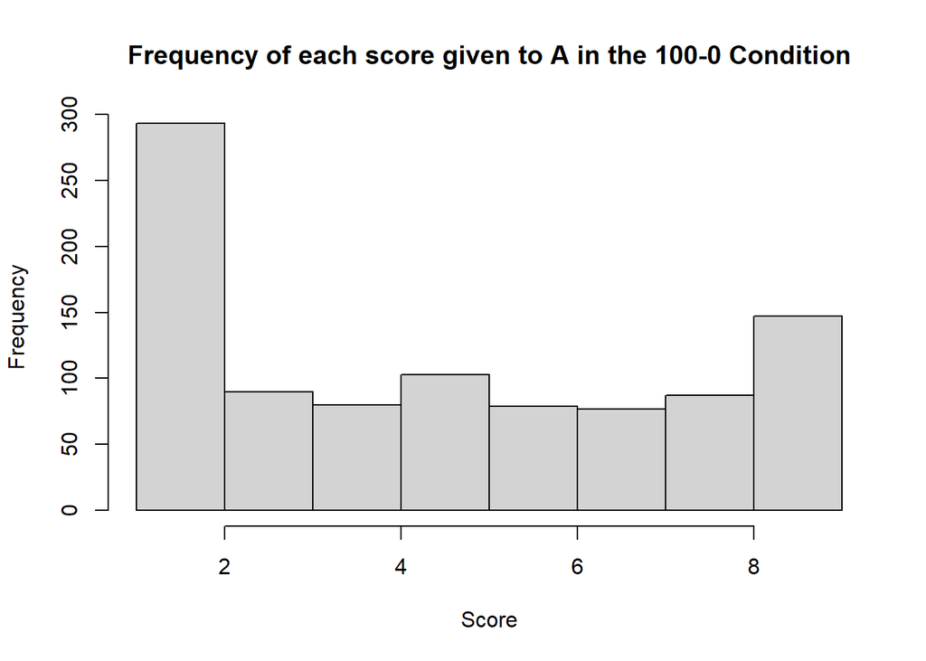

```r
hist(train$responseR1[train$Cond == "100"], breaks = 10, main = "Frequency of each score given to A in the 100-0 Condition", xlab = "Score")
```

```r
mean(train$responseR1[train$Cond == "100"], na.rm = TRUE)
```

```
## [1] 4.723849
```

This histogram shows the condition where A (responseR1) always leads to a diamond outcome. Which makes it so weird that there are so many 1’s in there

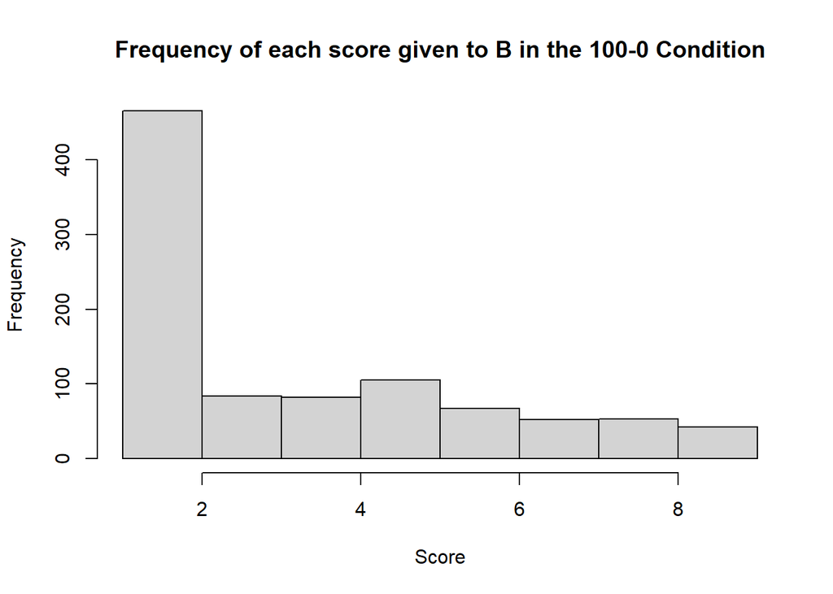

```r
hist(train$responseR2[train$Cond == "100"], breaks = 10, main = "Frequency of each score given to B in the 100-0 Condition", xlab = "Score")
```

```r
mean(train$responseR2[train$Cond == "100"], na.rm = TRUE)
```

```
## [1] 3.418947
```

This histogram shows the condition where B (responseR2) never leads to a diamond outcome. Here the amount of 1’s make more sense, and I’m glad to see that at least in comparison they differ?

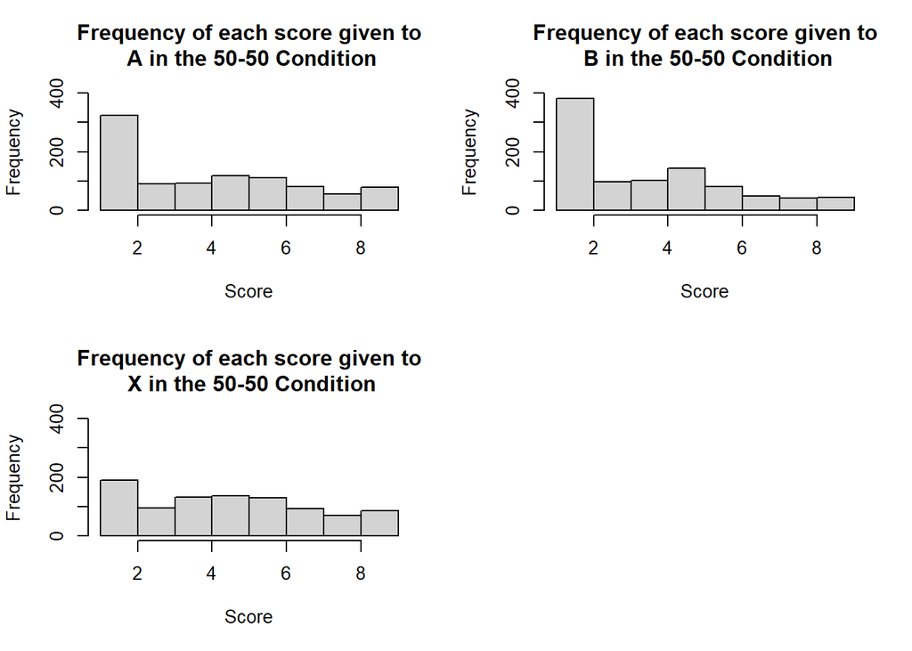

```r
par(mfrow = c(2,2))
hist(train$responseR1[train$Cond == "0"], breaks = 10, main = "Frequency of each score given to\n A in the 50-50 Condition", xlab = "Score", ylim = c(0,400))
hist(train$responseR2[train$Cond == "0"], breaks = 10, main = "Frequency of each score given to\n B in the 50-50 Condition", xlab = "Score", ylim = c(0,400))
hist(train$responseR3[train$Cond == "0"], breaks = 10, main = "Frequency of each score given to\n X in the 50-50 Condition", xlab = "Score", ylim = c(0,400))

par(mfrow = c(2,2))
```

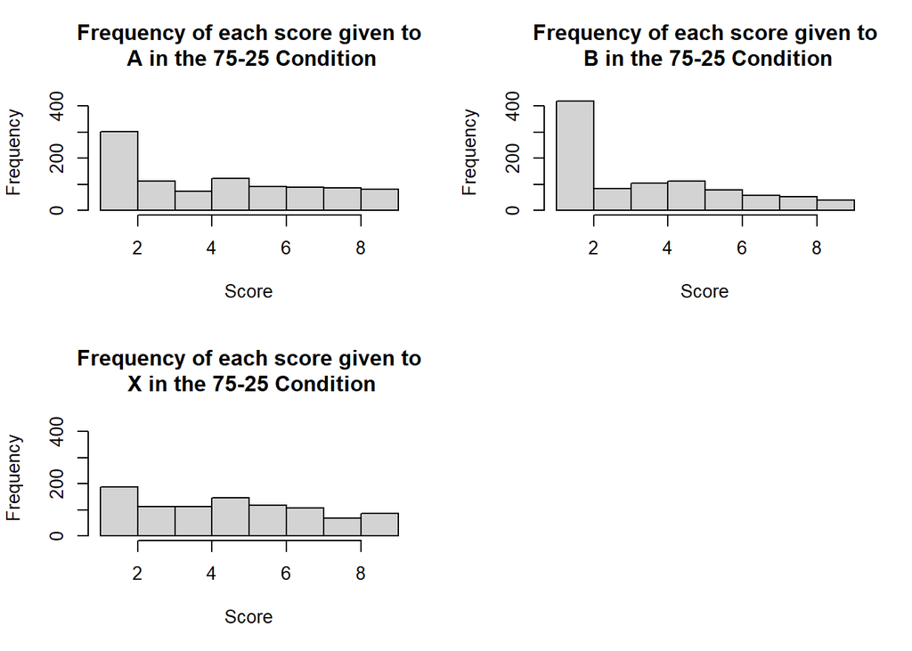

```r
hist(train$responseR1[train$Cond == "50"], breaks = 10, main = "Frequency of each score given to\n A in the 75-25 Condition", xlab = "Score", ylim = c(0,450))
hist(train$responseR2[train$Cond == "50"], breaks = 10, main = "Frequency of each score given to\n B in the 75-25 Condition", xlab = "Score", ylim = c(0,450))
hist(train$responseR3[train$Cond == "50"], breaks = 10, main = "Frequency of each score given to\n X in the 75-25 Condition", xlab = "Score", ylim = c(0,450))

par(mfrow = c(2,2))
```

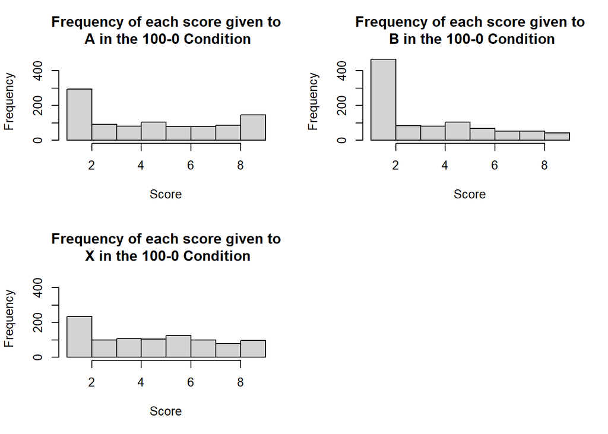

```r
hist(train$responseR1[train$Cond == "100"], breaks = 10, main = "Frequency of each score given to\n A in the 100-0 Condition", xlab = "Score", ylim = c(0,450))
hist(train$responseR2[train$Cond == "100"], breaks = 10, main = "Frequency of each score given to\n B in the 100-0 Condition", xlab = "Score", ylim = c(0,450))
hist(train$responseR3[train$Cond == "100"], breaks = 10, main = "Frequency of each score given to\n X in the 100-0 Condition", xlab = "Score", ylim = c(0,450))
```

## Numbers

```r
#As there are lots of 1's let's see how often people scored 1's on average for A B and X (over all conditions)

#Create a subset of data with just the 1's in there
OnesR1 <- subset(train, train$responseR1 == 1)
OnesR2 <- subset(train, train$responseR2 == 1)
OnesR3 <- subset(train, train$responseR3 == 1)
#Take the sum of these ones over participants (as we want to know how often (on average) one participant scored a 1 for A, B or X)
SumOnesR1 <- aggregate(OnesR1$responseR1, list(OnesR1$jatosStudyResultId), sum)
SumOnesR2 <- aggregate(OnesR2$responseR2, list(OnesR2$jatosStudyResultId), sum)
SumOnesR3 <- aggregate(OnesR3$responseR3, list(OnesR3$jatosStudyResultId), sum)
#then take the mean
AvgOnesR1 <- mean(SumOnesR1$x)
AvgOnesR2 <- mean(SumOnesR2$x)
AvgOnesR3 <- mean(SumOnesR3$x)
AvgOnesR1
```

```
## [1] 12.07843
```

```r
AvgOnesR2
```

```
## [1] 16.08929
```

```r
AvgOnesR3
```

```
## [1] 7.111111
```

The average amount of 1’s given to A is 12, which is 25% of all trails.  
The average amount of 1’s given to B is 16, which is 33,3% of all trials  
And the average amount of 1’s given to X is 7, which is 14,6% of all trials.  
You would expect that B is scored lower over all (as it’s the least predictive over all), and A to be scored higher over all, so have less 1’s than the rest. However what we see here is that X, the stimuli that always appears is actually scored 1 the least amount of times.

# Training phase

## Average plots

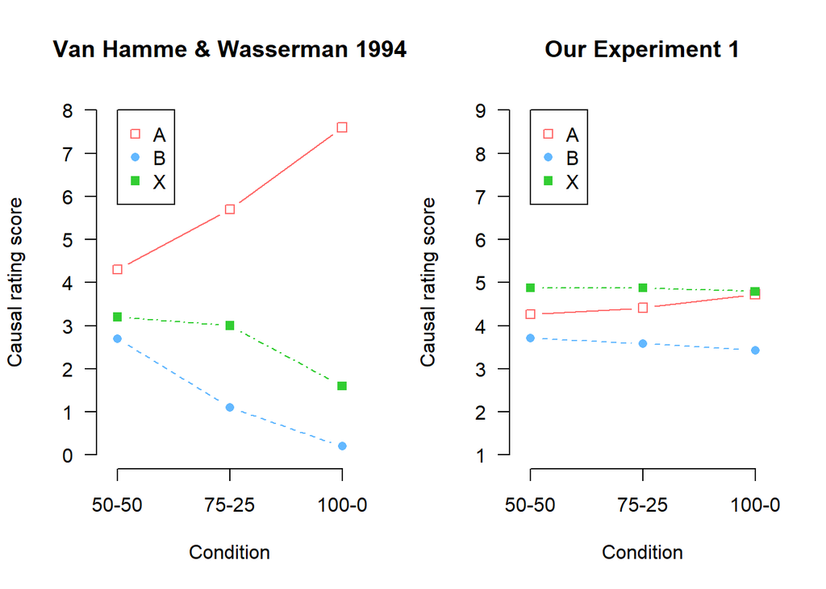

```r
par(mfrow = c(1,2))
par(las=1)
#original plot
emptyPlot(c(-5,105),c(0,8), xaxt = "none", ymark=c(0,1,2,3,4,5,6,7,8), bty='n', main = "Van Hamme & Wasserman 1994", xlab = "Condition", ylab = "Causal rating score")
A <- c(4.3,5.7,7.6)
B <- c(2.7, 1.1, 0.2)
X <- c(3.2,3,1.6)
points(c(0, 50, 100),A, pch = 0, type = "b", col = "indianred1")
points(c(0, 50, 100),B, pch =16, type = "b", lty = 2, col = "steelblue1")
points(c(0, 50, 100),X, pch =15, type = "b", lty = 4, col = "limegreen")
legend(0.05,8,legend =c("A", "B", "X"), pch = c(0,16,15), col = c("indianred1", "steelblue1", "limegreen"))
axis(1, at = c(0,50,100), labels = c("50-50", "75-25", "100-0"))

#Our experiment
emptyPlot(c(-5,105),c(1,9), xaxt = "none", ymark=c(1,2,3,4,5,6,7,8,9), bty='n', main = "Our Experiment 1", xlab = "Condition", ylab = "Causal rating score")
A <- c(a$A)
B <- c(a$B)
X <- c(a$X)
points(c(0, 50, 100),A, pch = 0, type = "b", col = "indianred1")
points(c(0, 50, 100),B, pch =16, type = "b", lty = 2, col = "steelblue1")
points(c(0, 50, 100),X, pch =15, type = "b", lty = 4, col = "limegreen")
legend(0.05,9,legend =c("A", "B", "X"), pch = c(0,16,15), col = c("indianred1", "steelblue1", "limegreen"))
axis(1, at = c(0,50,100), labels = c("50-50", "75-25", "100-0"))
```

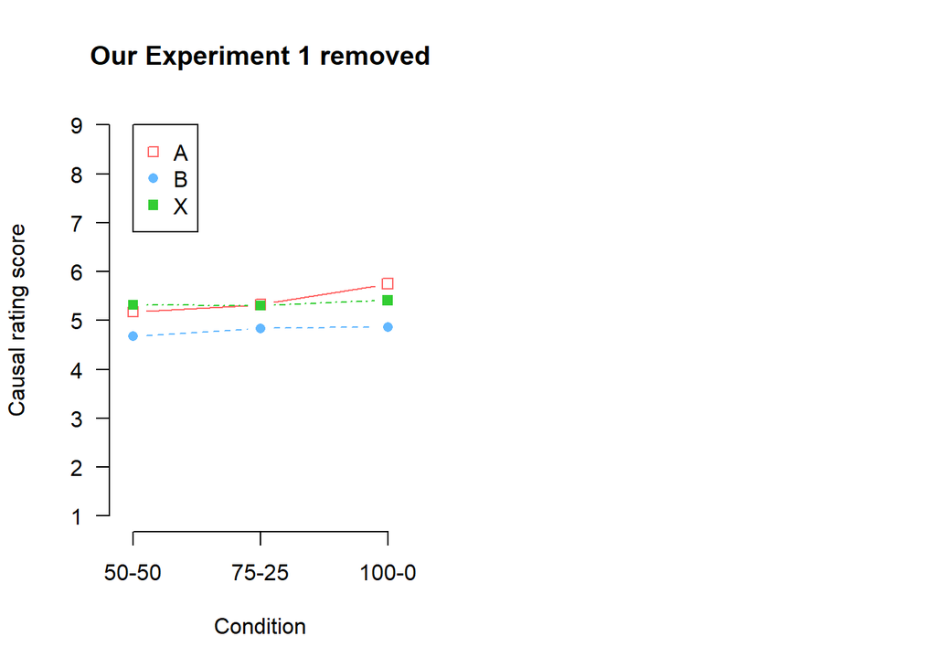

```r
#Our experiment with 1's removed
emptyPlot(c(-5,105),c(1,9), xaxt = "none", ymark=c(1,2,3,4,5,6,7,8,9), bty='n', main = "Our Experiment 1 removed", xlab = "Condition", ylab = "Causal rating score")
A <- c(b$A)
B <- c(b$B)
X <- c(b$X)
points(c(0, 50, 100),A, pch = 0, type = "b", col = "indianred1")
points(c(0, 50, 100),B, pch =16, type = "b", lty = 2, col = "steelblue1")
points(c(0, 50, 100),X, pch =15, type = "b", lty = 4, col = "limegreen")
legend(0.05,9,legend =c("A", "B", "X"), pch = c(0,16,15), col = c("indianred1", "steelblue1", "limegreen"))
axis(1, at = c(0,50,100), labels = c("50-50", "75-25", "100-0"))
```

### Averages but with thicker lines

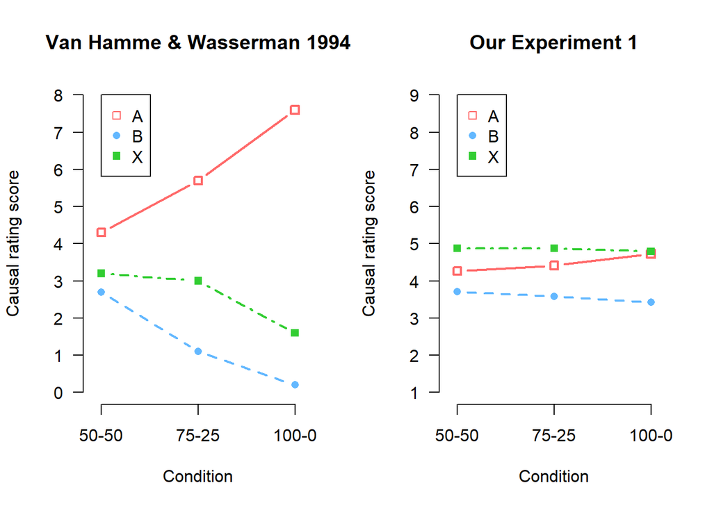

```r
par(mfrow = c(1,2))
par(las=1)
#original plot
emptyPlot(c(-5,105),c(0,8), xaxt = "none", ymark=c(0,1,2,3,4,5,6,7,8), bty='n', main = "Van Hamme & Wasserman 1994", xlab = "Condition", ylab = "Causal rating score")
A <- c(4.3,5.7,7.6)
B <- c(2.7, 1.1, 0.2)
X <- c(3.2,3,1.6)
points(c(0, 50, 100),A, pch = 0, type = "b", col = "indianred1", lwd = 2)
points(c(0, 50, 100),B, pch =16, type = "b", lty = 2, col = "steelblue1", lwd = 2)
points(c(0, 50, 100),X, pch =15, type = "b", lty = 4, col = "limegreen", lwd = 2)
legend(0.05,8,legend =c("A", "B", "X"), pch = c(0,16,15), col = c("indianred1", "steelblue1", "limegreen"))
axis(1, at = c(0,50,100), labels = c("50-50", "75-25", "100-0"))

#Our experiment
emptyPlot(c(-5,105),c(1,9), xaxt = "none", ymark=c(1,2,3,4,5,6,7,8,9), bty='n', main = "Our Experiment 1", xlab = "Condition", ylab = "Causal rating score")
A <- c(a$A)
B <- c(a$B)
X <- c(a$X)
points(c(0, 50, 100),A, pch = 0, type = "b", col = "indianred1", lwd = 2)
points(c(0, 50, 100),B, pch =16, type = "b", lty = 2, col = "steelblue1", lwd = 2)
points(c(0, 50, 100),X, pch =15, type = "b", lty = 4, col = "limegreen", lwd = 2)
legend(0.05,9,legend =c("A", "B", "X"), pch = c(0,16,15), col = c("indianred1", "steelblue1", "limegreen"))
axis(1, at = c(0,50,100), labels = c("50-50", "75-25", "100-0"))
```

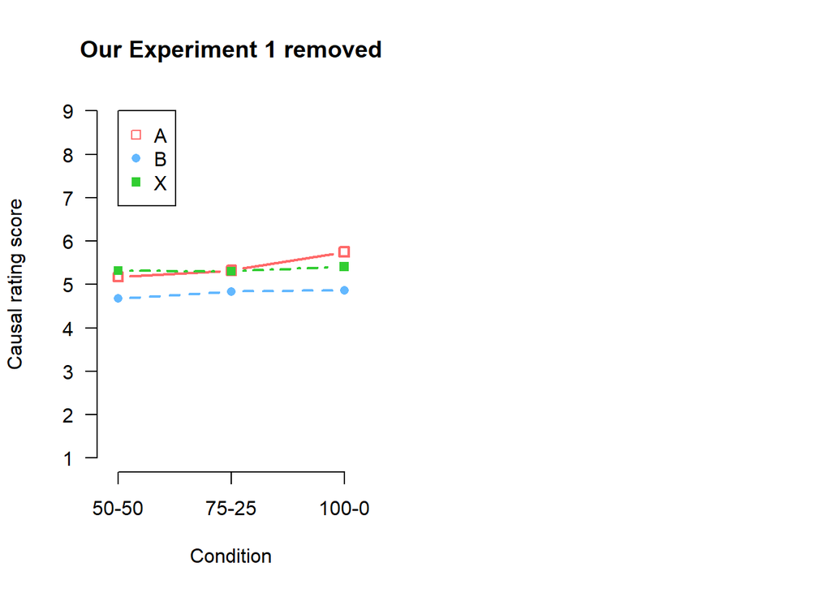

```r
#Our experiment with 1's removed
emptyPlot(c(-5,105),c(1,9), xaxt = "none", ymark=c(1,2,3,4,5,6,7,8,9), bty='n', main = "Our Experiment 1 removed", xlab = "Condition", ylab = "Causal rating score")
A <- c(b$A)
B <- c(b$B)
X <- c(b$X)
points(c(0, 50, 100),A, pch = 0, type = "b", col = "indianred1", lwd = 2)
points(c(0, 50, 100),B, pch =16, type = "b", lty = 2, col = "steelblue1", lwd = 2)
points(c(0, 50, 100),X, pch =15, type = "b", lty = 4, col = "limegreen", lwd = 2)
legend(0.05,9,legend =c("A", "B", "X"), pch = c(0,16,15), col = c("indianred1", "steelblue1", "limegreen"))
axis(1, at = c(0,50,100), labels = c("50-50", "75-25", "100-0"))
```

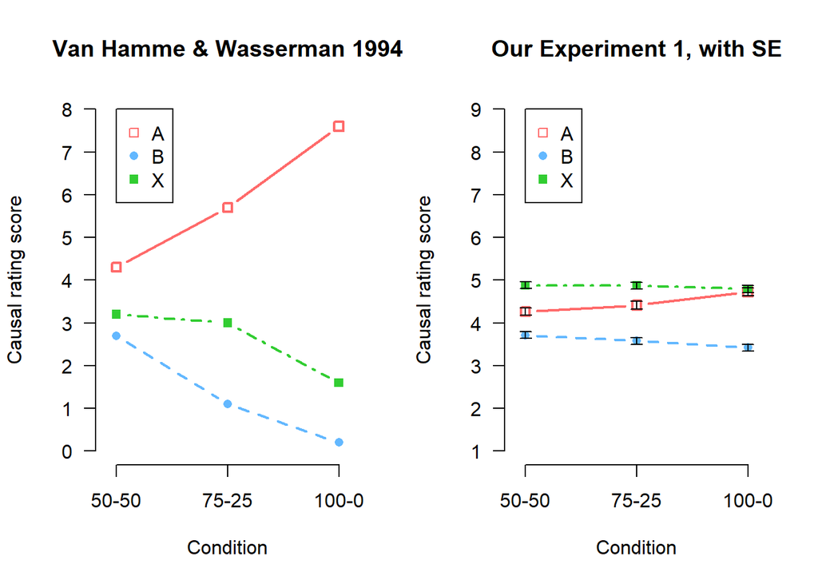

```r
par(mfrow = c(1,2))
par(las=1)
#original plot
emptyPlot(c(-5,105),c(0,8), xaxt = "none", ymark=c(0,1,2,3,4,5,6,7,8), bty='n', main = "Van Hamme & Wasserman 1994", xlab = "Condition", ylab = "Causal rating score")
A <- c(4.3,5.7,7.6)
B <- c(2.7, 1.1, 0.2)
X <- c(3.2,3,1.6)
points(c(0, 50, 100),A, pch = 0, type = "b", col = "indianred1", lwd = 2)
points(c(0, 50, 100),B, pch =16, type = "b", lty = 2, col = "steelblue1", lwd = 2)
points(c(0, 50, 100),X, pch =15, type = "b", lty = 4, col = "limegreen", lwd = 2)
legend(0.05,8,legend =c("A", "B", "X"), pch = c(0,16,15), col = c("indianred1", "steelblue1", "limegreen"))
axis(1, at = c(0,50,100), labels = c("50-50", "75-25", "100-0"))

#Our experiment
emptyPlot(c(-5,105),c(1,9), xaxt = "none", ymark=c(1,2,3,4,5,6,7,8,9), bty='n', main = "Our Experiment 1, with SE", xlab = "Condition", ylab = "Causal rating score")
A <- c(a$A)
B <- c(a$B)
X <- c(a$X)
points(c(0, 50, 100),A, pch = 0, type = "b", col = "indianred1", lwd = 2)
points(c(0, 50, 100),B, pch =16, type = "b", lty = 2, col = "steelblue1", lwd = 2)
points(c(0, 50, 100),X, pch =15, type = "b", lty = 4, col = "limegreen", lwd = 2)
legend(0.05,9,legend =c("A", "B", "X"), pch = c(0,16,15), col = c("indianred1", "steelblue1", "limegreen"))
errorbars(x= c(0,50,100), y = a$A, top = SECondA, bottom = SECondA, add = TRUE, length = 0.05)
errorbars(x= c(0,50,100), y = a$B, top = SECondB, bottom = SECondB, add = TRUE, length = 0.05)
errorbars(x= c(0,50,100), y = a$X, top = SECondX, bottom = SECondX, add = TRUE, length = 0.05)
axis(1, at = c(0,50,100), labels = c("50-50", "75-25", "100-0"))
```

## Condition 50-50

### Cond 000

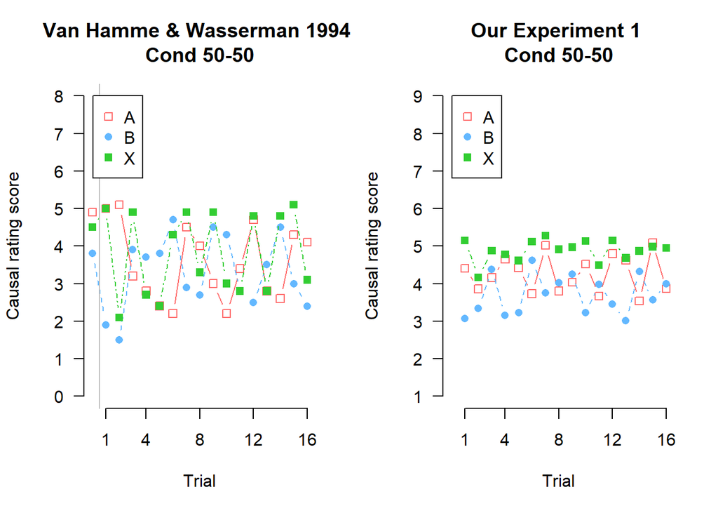

```r
par(mfrow = c(1,2))
par(las=1)
#original plot
emptyPlot(c(0,16),c(0,8), xmark = c(1,4,8,12,16), ymark=c(0,1,2,3,4,5,6,7,8), bty='n', main = "Van Hamme & Wasserman 1994 \nCond 50-50", xlab = "Trial", ylab = "Causal rating score")
A <- c(4.9, 5, 5.1, 3.2, 2.8, 2.4, 2.2, 4.5, 4, 3, 2.2, 3.4, 4.7, 2.8, 2.6, 4.3, 4.1)
B <- c(3.8, 1.9, 1.5, 3.9, 3.7, 3.8, 4.7, 2.9, 2.7, 4.5, 4.3, 2.8, 2.5, 3.5, 4.5, 3, 2.4)
X <- c(4.5, 5, 2.1, 4.9, 2.7, 2.4, 4.3, 4.9, 3.3, 4.9, 3, 2.8, 4.8,2.8, 4.8, 5.1, 3.1)
points(c(0:16),A, pch = 0, type = "b", col = "indianred1")
points(c(0:16),B, pch =16, type = "b", lty = 2, col = "steelblue1")
points(c(0:16),X, pch =15, type = "b", lty = 4, col = "limegreen")
abline(v=0.5, col="grey", lty = 1)
legend(0.05,8,legend =c("A", "B", "X"), pch = c(0,16,15), col = c("indianred1", "steelblue1", "limegreen"))

emptyPlot(c(0,16),c(1,9), xmark = c(1,4,8,12,16), ymark=c(1,2,3,4,5,6,7,8, 9), bty='n', main = "Our Experiment 1 \nCond 50-50", xlab = "Trial", ylab = "Causal rating score")
A <- Cond000$A
B <- Cond000$B
X <- Cond000$X
points(c(1:16),A, pch = 0, type = "b", col = "indianred1")
points(c(1:16),B, pch =16, type = "b", lty = 2, col = "steelblue1")
points(c(1:16),X, pch =15, type = "b", lty = 4, col = "limegreen")
legend(0.05,9,legend =c("A", "B", "X"), pch = c(0,16,15), col = c("indianred1", "steelblue1", "limegreen"))
```

### Cond 000 Thick lines

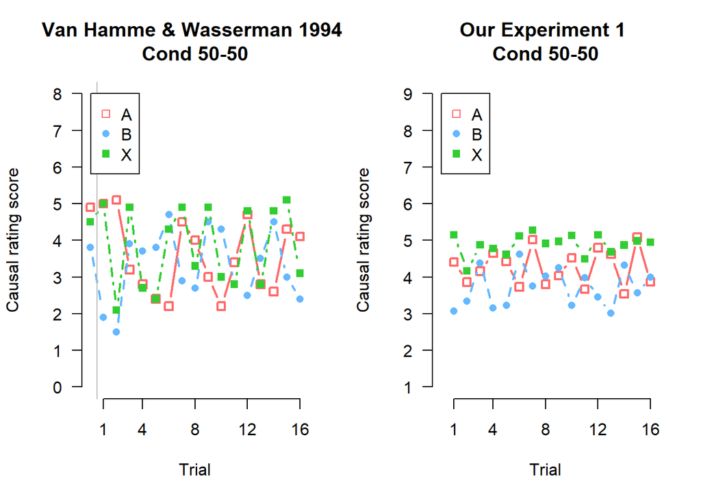

```r
par(mfrow = c(1,2))
par(las=1)
#original plot
emptyPlot(c(0,16),c(0,8), xmark = c(1,4,8,12,16), ymark=c(0,1,2,3,4,5,6,7,8), bty='n', main = "Van Hamme & Wasserman 1994 \nCond 50-50", xlab = "Trial", ylab = "Causal rating score")
A <- c(4.9, 5, 5.1, 3.2, 2.8, 2.4, 2.2, 4.5, 4, 3, 2.2, 3.4, 4.7, 2.8, 2.6, 4.3, 4.1)
B <- c(3.8, 1.9, 1.5, 3.9, 3.7, 3.8, 4.7, 2.9, 2.7, 4.5, 4.3, 2.8, 2.5, 3.5, 4.5, 3, 2.4)
X <- c(4.5, 5, 2.1, 4.9, 2.7, 2.4, 4.3, 4.9, 3.3, 4.9, 3, 2.8, 4.8,2.8, 4.8, 5.1, 3.1)
points(c(0:16),A, pch = 0, type = "b", col = "indianred1", lwd = 2)
points(c(0:16),B, pch =16, type = "b", lty = 2, col = "steelblue1", lwd = 2)
points(c(0:16),X, pch =15, type = "b", lty = 4, col = "limegreen", lwd = 2)
abline(v=0.5, col="grey", lty = 1)
legend(0.05,8,legend =c("A", "B", "X"), pch = c(0,16,15), col = c("indianred1", "steelblue1", "limegreen"))

emptyPlot(c(0,16),c(1,9), xmark = c(1,4,8,12,16), ymark=c(1,2,3,4,5,6,7,8, 9), bty='n', main = "Our Experiment 1 \nCond 50-50", xlab = "Trial", ylab = "Causal rating score")
A <- Cond000$A
B <- Cond000$B
X <- Cond000$X
points(c(1:16),A, pch = 0, type = "b", col = "indianred1", lwd = 2)
points(c(1:16),B, pch =16, type = "b", lty = 2, col = "steelblue1" , lwd = 2)
points(c(1:16),X, pch =15, type = "b", lty = 4, col = "limegreen", lwd = 2)
legend(0.05,9,legend =c("A", "B", "X"), pch = c(0,16,15), col = c("indianred1", "steelblue1", "limegreen"))
```

### Cond 000 SE bars

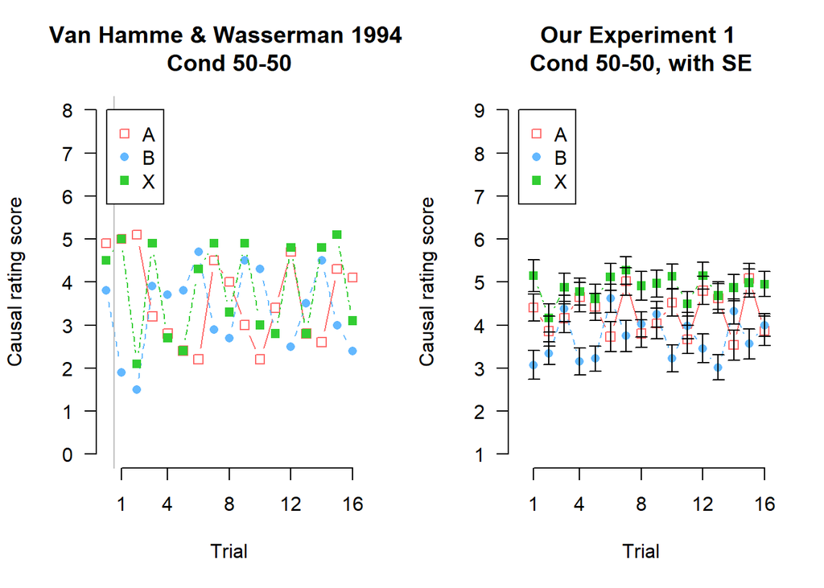

```r
par(mfrow = c(1,2))
par(las=1)
#original plot
emptyPlot(c(0,16),c(0,8), xmark = c(1,4,8,12,16), ymark=c(0,1,2,3,4,5,6,7,8), bty='n', main = "Van Hamme & Wasserman 1994 \nCond 50-50", xlab = "Trial", ylab = "Causal rating score")
A <- c(4.9, 5, 5.1, 3.2, 2.8, 2.4, 2.2, 4.5, 4, 3, 2.2, 3.4, 4.7, 2.8, 2.6, 4.3, 4.1)
B <- c(3.8, 1.9, 1.5, 3.9, 3.7, 3.8, 4.7, 2.9, 2.7, 4.5, 4.3, 2.8, 2.5, 3.5, 4.5, 3, 2.4)
X <- c(4.5, 5, 2.1, 4.9, 2.7, 2.4, 4.3, 4.9, 3.3, 4.9, 3, 2.8, 4.8,2.8, 4.8, 5.1, 3.1)
points(c(0:16),A, pch = 0, type = "b", col = "indianred1")
points(c(0:16),B, pch =16, type = "b", lty = 2, col = "steelblue1")
points(c(0:16),X, pch =15, type = "b", lty = 4, col = "limegreen")
abline(v=0.5, col="grey", lty = 1)
legend(0.05,8,legend =c("A", "B", "X"), pch = c(0,16,15), col = c("indianred1", "steelblue1", "limegreen"))

emptyPlot(c(0,16),c(1,9), xmark = c(1,4,8,12,16), ymark=c(1,2,3,4,5,6,7,8, 9), bty='n', main = "Our Experiment 1 \nCond 50-50, with SE", xlab = "Trial", ylab = "Causal rating score")
A <- Cond000$A
B <- Cond000$B
X <- Cond000$X
points(c(1:16),A, pch = 0, type = "b", col = "indianred1")
points(c(1:16),B, pch =16, type = "b", lty = 2, col = "steelblue1")
points(c(1:16),X, pch =15, type = "b", lty = 4, col = "limegreen")
errorbars(x= c(1:16), y = Cond000$A, top = SETrials000A, bottom = SETrials000A, add = TRUE, length = 0.05)
errorbars(x= c(1:16), y = Cond000$B, top = SETrials000B, bottom = SETrials000B, add = TRUE, length = 0.05)
errorbars(x= c(1:16), y = Cond000$X, top = SETrials000X, bottom = SETrials000X, add = TRUE, length = 0.05)
legend(0.05,9,legend =c("A", "B", "X"), pch = c(0,16,15), col = c("indianred1", "steelblue1", "limegreen"))
```

## Condition 75-25

### Cond 050

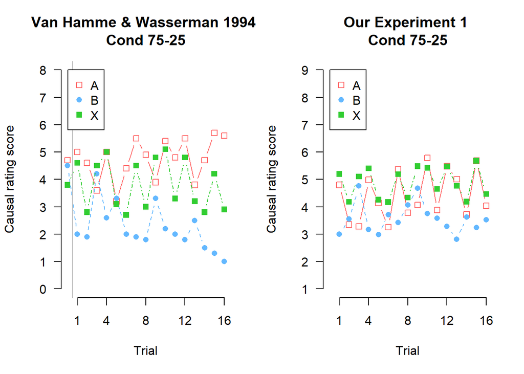

```r
par(mfrow = c(1,2))
par(las=1)
#original plot
emptyPlot(c(0,16),c(0,8), xmark = c(1,4,8,12,16), ymark=c(0,1,2,3,4,5,6,7,8), bty='n', main = "Van Hamme & Wasserman 1994 \nCond 75-25", xlab = "Trial", ylab = "Causal rating score")
A <- c(4.7,5,4.6,3.6,5,3.2,4.4,5.5,4.9,3.9,5.4,4.8,5.5,3.8,4.7,5.7,5.6)
B <- c(4.5,2,1.9,4.2,2.6,3.3,2,1.9,1.8,3.3,2.2,2,1.8,2.5,1.5,1.3,1)
X <- c(3.8,4.6,2.8,4.5,5,3.1,2.7,4.5,3,4.8,5.1,3.3,4.8,3.2,2.8,4.2,2.9)
points(c(0:16),A, pch = 0, type = "b", col = "indianred1")
points(c(0:16),B, pch =16, type = "b", lty = 2, col = "steelblue1")
points(c(0:16),X, pch =15, type = "b", lty = 4, col = "limegreen")
abline(v=0.5, col="grey", lty = 1)
legend(0.05,8,legend =c("A", "B", "X"), pch = c(0,16,15), col = c("indianred1", "steelblue1", "limegreen"))


emptyPlot(c(0,16),c(1,9), xmark = c(1,4,8,12,16), ymark=c(1,2,3,4,5,6,7,8, 9), bty='n', main = "Our Experiment 1 \nCond 75-25", xlab = "Trial", ylab = "Causal rating score")
A <- Cond050$A
B <- Cond050$B
X <- Cond050$X
points(c(1:16),A, pch = 0, type = "b", col = "indianred1")
points(c(1:16),B, pch =16, type = "b", lty = 2, col = "steelblue1")
points(c(1:16),X, pch =15, type = "b", lty = 4, col = "limegreen")
legend(0.05,9,legend =c("A", "B", "X"), pch = c(0,16,15), col = c("indianred1", "steelblue1", "limegreen"))
```

### Cond 050 Thicker lines

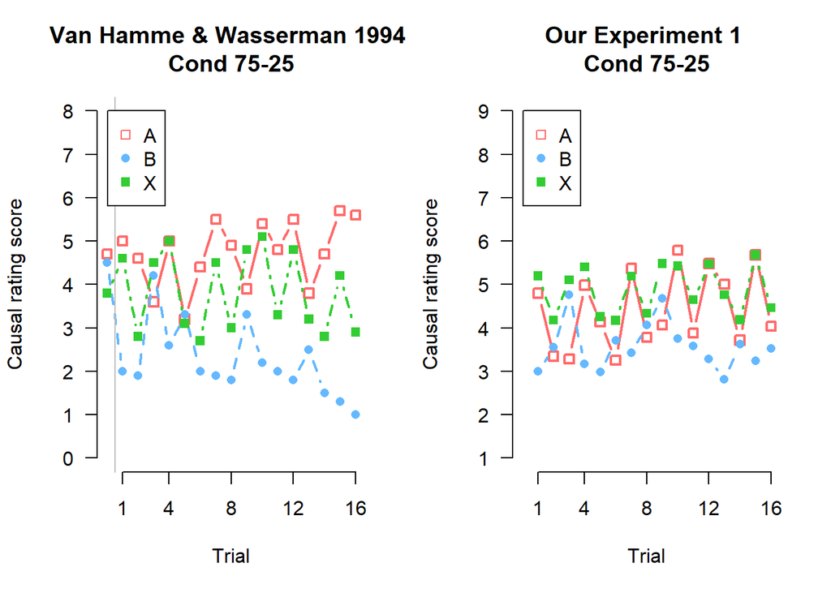

```r
par(mfrow = c(1,2))
par(las=1)
#original plot
emptyPlot(c(0,16),c(0,8), xmark = c(1,4,8,12,16), ymark=c(0,1,2,3,4,5,6,7,8), bty='n', main = "Van Hamme & Wasserman 1994 \nCond 75-25", xlab = "Trial", ylab = "Causal rating score")
A <- c(4.7,5,4.6,3.6,5,3.2,4.4,5.5,4.9,3.9,5.4,4.8,5.5,3.8,4.7,5.7,5.6)
B <- c(4.5,2,1.9,4.2,2.6,3.3,2,1.9,1.8,3.3,2.2,2,1.8,2.5,1.5,1.3,1)
X <- c(3.8,4.6,2.8,4.5,5,3.1,2.7,4.5,3,4.8,5.1,3.3,4.8,3.2,2.8,4.2,2.9)
points(c(0:16),A, pch = 0, type = "b", col = "indianred1", lwd = 2)
points(c(0:16),B, pch =16, type = "b", lty = 2, col = "steelblue1", lwd = 2)
points(c(0:16),X, pch =15, type = "b", lty = 4, col = "limegreen", lwd = 2)
abline(v=0.5, col="grey", lty = 1)
legend(0.05,8,legend =c("A", "B", "X"), pch = c(0,16,15), col = c("indianred1", "steelblue1", "limegreen"))


emptyPlot(c(0,16),c(1,9), xmark = c(1,4,8,12,16), ymark=c(1,2,3,4,5,6,7,8, 9), bty='n', main = "Our Experiment 1 \nCond 75-25", xlab = "Trial", ylab = "Causal rating score")
A <- Cond050$A
B <- Cond050$B
X <- Cond050$X
points(c(1:16),A, pch = 0, type = "b", col = "indianred1", lwd = 2)
points(c(1:16),B, pch =16, type = "b", lty = 2, col = "steelblue1", lwd = 2)
points(c(1:16),X, pch =15, type = "b", lty = 4, col = "limegreen", lwd = 2)
legend(0.05,9,legend =c("A", "B", "X"), pch = c(0,16,15), col = c("indianred1", "steelblue1", "limegreen"))
```

### Cond 050 SE bars

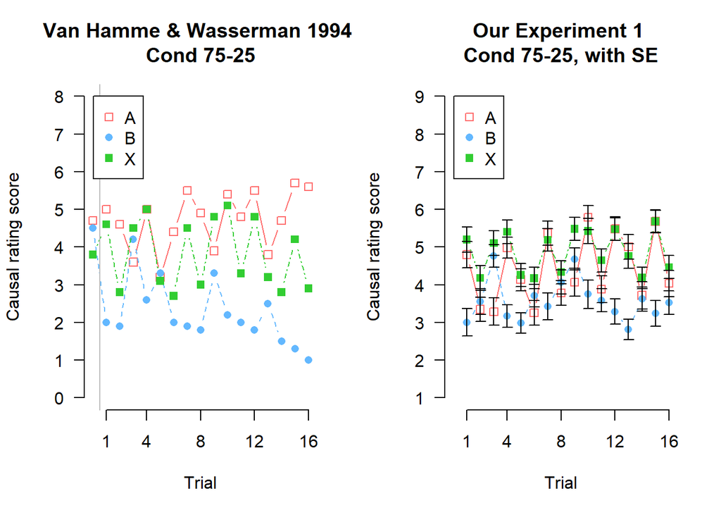

```r
par(mfrow = c(1,2))
par(las=1)
#original plot
emptyPlot(c(0,16),c(0,8), xmark = c(1,4,8,12,16), ymark=c(0,1,2,3,4,5,6,7,8), bty='n', main = "Van Hamme & Wasserman 1994 \nCond 75-25", xlab = "Trial", ylab = "Causal rating score")
A <- c(4.7,5,4.6,3.6,5,3.2,4.4,5.5,4.9,3.9,5.4,4.8,5.5,3.8,4.7,5.7,5.6)
B <- c(4.5,2,1.9,4.2,2.6,3.3,2,1.9,1.8,3.3,2.2,2,1.8,2.5,1.5,1.3,1)
X <- c(3.8,4.6,2.8,4.5,5,3.1,2.7,4.5,3,4.8,5.1,3.3,4.8,3.2,2.8,4.2,2.9)
points(c(0:16),A, pch = 0, type = "b", col = "indianred1")
points(c(0:16),B, pch =16, type = "b", lty = 2, col = "steelblue1")
points(c(0:16),X, pch =15, type = "b", lty = 4, col = "limegreen")
abline(v=0.5, col="grey", lty = 1)
legend(0.05,8,legend =c("A", "B", "X"), pch = c(0,16,15), col = c("indianred1", "steelblue1", "limegreen"))


emptyPlot(c(0,16),c(1,9), xmark = c(1,4,8,12,16), ymark=c(1,2,3,4,5,6,7,8, 9), bty='n', main = "Our Experiment 1 \nCond 75-25, with SE", xlab = "Trial", ylab = "Causal rating score")
A <- Cond050$A
B <- Cond050$B
X <- Cond050$X
points(c(1:16),A, pch = 0, type = "b", col = "indianred1")
points(c(1:16),B, pch =16, type = "b", lty = 2, col = "steelblue1")
points(c(1:16),X, pch =15, type = "b", lty = 4, col = "limegreen")
errorbars(x= c(1:16), y = Cond050$A, top = SETrials050A, bottom = SETrials050A, add = TRUE, length = 0.05)
errorbars(x= c(1:16), y = Cond050$B, top = SETrials050B, bottom = SETrials050B, add = TRUE, length = 0.05)
errorbars(x= c(1:16), y = Cond050$X, top = SETrials050X, bottom = SETrials050X, add = TRUE, length = 0.05)
legend(0.05,9,legend =c("A", "B", "X"), pch = c(0,16,15), col = c("indianred1", "steelblue1", "limegreen"))
```

## Condition 100-0

### Cond 100

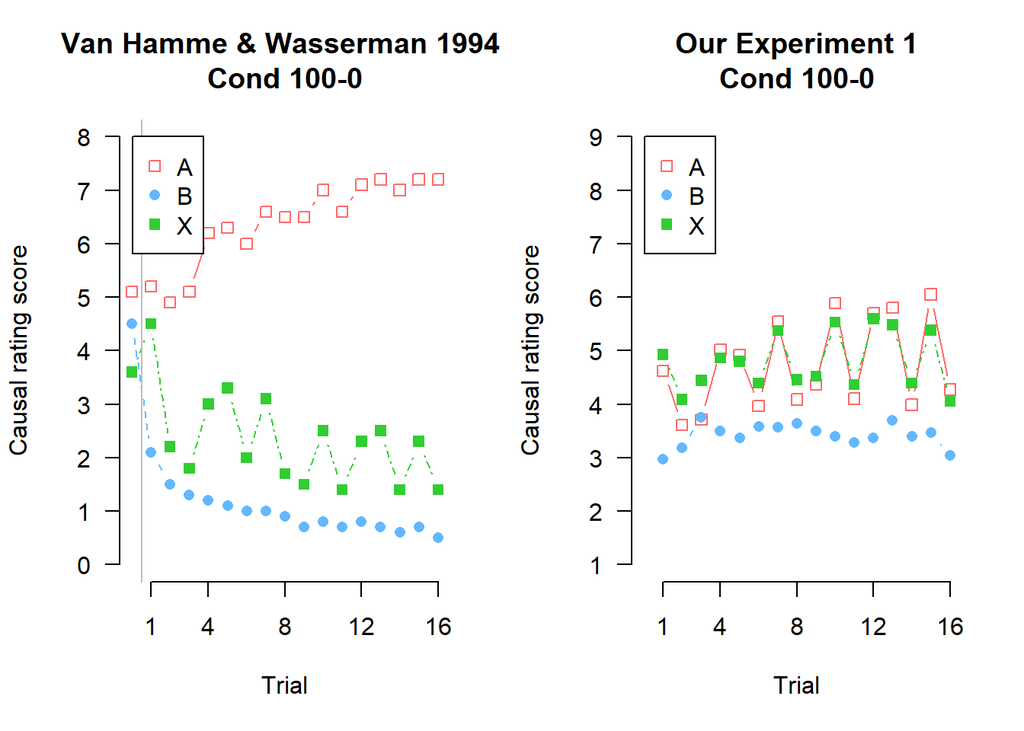

```r
par(mfrow = c(1,2))
par(las=1)
#original plot
emptyPlot(c(0,16),c(0,8), xmark = c(1,4,8,12,16), ymark=c(0,1,2,3,4,5,6,7,8), bty='n', main = "Van Hamme & Wasserman 1994 \nCond 100-0", xlab = "Trial", ylab = "Causal rating score")
A <- c(5.1,5.2,4.9,5.1,6.2,6.3,6,6.6,6.5,6.5,7,6.6,7.1,7.2,7,7.2,7.2)
B <- c(4.5,2.1,1.5,1.3,1.2,1.1,1,1,0.9,0.7,0.8,0.7,0.8,0.7,0.6,0.7,0.5)
X <- c(3.6,4.5,2.2,1.8,3,3.3,2,3.1,1.7,1.5,2.5,1.4,2.3,2.5,1.4,2.3,1.4)
points(c(0:16),A, pch = 0, type = "b", col = "indianred1")
points(c(0:16),B, pch =16, type = "b", lty = 2, col = "steelblue1")
points(c(0:16),X, pch =15, type = "b", lty = 4, col = "limegreen")
abline(v=0.5, col="grey", lty = 1)
legend(0.05,8,legend =c("A", "B", "X"), pch = c(0,16,15), col = c("indianred1", "steelblue1", "limegreen"))

emptyPlot(c(0,16),c(1,9), xmark = c(1,4,8,12,16), ymark=c(1,2,3,4,5,6,7,8, 9), bty='n', main = "Our Experiment 1\nCond 100-0", xlab = "Trial", ylab = "Causal rating score")
A <- Cond100$A
B <- Cond100$B
X <- Cond100$X
points(c(1:16),A, pch = 0, type = "b", col = "indianred1")
points(c(1:16),B, pch =16, type = "b", lty = 2, col = "steelblue1")
points(c(1:16),X, pch =15, type = "b", lty = 4, col = "limegreen")
legend(0.05,9,legend =c("A", "B", "X"), pch = c(0,16,15), col = c("indianred1", "steelblue1", "limegreen"))
```

### Cond 100 Thicker lines

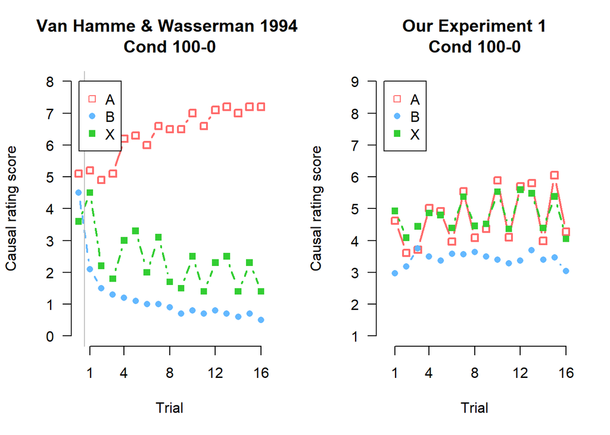

```r
par(mfrow = c(1,2))
par(las=1)
#original plot
emptyPlot(c(0,16),c(0,8), xmark = c(1,4,8,12,16), ymark=c(0,1,2,3,4,5,6,7,8), bty='n', main = "Van Hamme & Wasserman 1994 \nCond 100-0", xlab = "Trial", ylab = "Causal rating score")
A <- c(5.1,5.2,4.9,5.1,6.2,6.3,6,6.6,6.5,6.5,7,6.6,7.1,7.2,7,7.2,7.2)
B <- c(4.5,2.1,1.5,1.3,1.2,1.1,1,1,0.9,0.7,0.8,0.7,0.8,0.7,0.6,0.7,0.5)
X <- c(3.6,4.5,2.2,1.8,3,3.3,2,3.1,1.7,1.5,2.5,1.4,2.3,2.5,1.4,2.3,1.4)
points(c(0:16),A, pch = 0, type = "b", col = "indianred1", lwd = 2)
points(c(0:16),B, pch =16, type = "b", lty = 2, col = "steelblue1", lwd = 2)
points(c(0:16),X, pch =15, type = "b", lty = 4, col = "limegreen", lwd = 2)
abline(v=0.5, col="grey", lty = 1)
legend(0.05,8,legend =c("A", "B", "X"), pch = c(0,16,15), col = c("indianred1", "steelblue1", "limegreen"))

emptyPlot(c(0,16),c(1,9), xmark = c(1,4,8,12,16), ymark=c(1,2,3,4,5,6,7,8, 9), bty='n', main = "Our Experiment 1\nCond 100-0", xlab = "Trial", ylab = "Causal rating score")
A <- Cond100$A
B <- Cond100$B
X <- Cond100$X
points(c(1:16),A, pch = 0, type = "b", col = "indianred1", lwd = 2)
points(c(1:16),B, pch =16, type = "b", lty = 2, col = "steelblue1", lwd = 2)
points(c(1:16),X, pch =15, type = "b", lty = 4, col = "limegreen", lwd = 2)
legend(0.05,9,legend =c("A", "B", "X"), pch = c(0,16,15), col = c("indianred1", "steelblue1", "limegreen"))
```

### Cond 100 SE

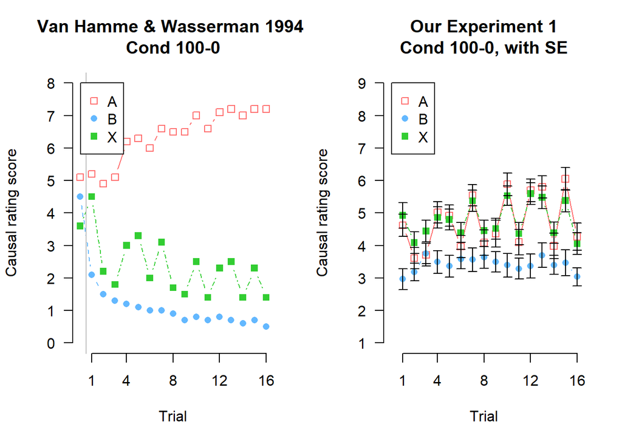

```r
par(mfrow = c(1,2))
par(las=1)
#original plot
emptyPlot(c(0,16),c(0,8), xmark = c(1,4,8,12,16), ymark=c(0,1,2,3,4,5,6,7,8), bty='n', main = "Van Hamme & Wasserman 1994 \nCond 100-0", xlab = "Trial", ylab = "Causal rating score")
A <- c(5.1,5.2,4.9,5.1,6.2,6.3,6,6.6,6.5,6.5,7,6.6,7.1,7.2,7,7.2,7.2)
B <- c(4.5,2.1,1.5,1.3,1.2,1.1,1,1,0.9,0.7,0.8,0.7,0.8,0.7,0.6,0.7,0.5)
X <- c(3.6,4.5,2.2,1.8,3,3.3,2,3.1,1.7,1.5,2.5,1.4,2.3,2.5,1.4,2.3,1.4)
points(c(0:16),A, pch = 0, type = "b", col = "indianred1")
points(c(0:16),B, pch =16, type = "b", lty = 2, col = "steelblue1")
points(c(0:16),X, pch =15, type = "b", lty = 4, col = "limegreen")
abline(v=0.5, col="grey", lty = 1)
legend(0.05,8,legend =c("A", "B", "X"), pch = c(0,16,15), col = c("indianred1", "steelblue1", "limegreen"))

emptyPlot(c(0,16),c(1,9), xmark = c(1,4,8,12,16), ymark=c(1,2,3,4,5,6,7,8, 9), bty='n', main = "Our Experiment 1\nCond 100-0, with SE", xlab = "Trial", ylab = "Causal rating score")
A <- Cond100$A
B <- Cond100$B
X <- Cond100$X
points(c(1:16),A, pch = 0, type = "b", col = "indianred1")
points(c(1:16),B, pch =16, type = "b", lty = 2, col = "steelblue1")
points(c(1:16),X, pch =15, type = "b", lty = 4, col = "limegreen")
errorbars(x= c(1:16), y = Cond100$A, top = SETrials100A, bottom = SETrials100A, add = TRUE, length = 0.05)
errorbars(x= c(1:16), y = Cond100$B, top = SETrials100B, bottom = SETrials100B, add = TRUE, length = 0.05)
errorbars(x= c(1:16), y = Cond100$X, top = SETrials100X, bottom = SETrials100X, add = TRUE, length = 0.05)
legend(0.05,9,legend =c("A", "B", "X"), pch = c(0,16,15), col = c("indianred1", "steelblue1", "limegreen"))
```

## Plotting participants over the whole experiment

```r
#randomly pick 5 participants (and keep those same participants, so the random is only for picking them the first time)
#sample(unique(dat$prolific_id), 5, replace = TRUE)
#gives us:
#5ed558bb9c43bc0d1ad52987 5edd1c649e50c2a126f60b17 5fc6b25adb97a63895d5435f 5f77909866be1b30356654c1 6004121207eaeb51c23d8b93

#so I'll plot those five people
P1 <- subset(train, train$prolific_id == "5ed558bb9c43bc0d1ad52987")
P2 <- subset(train, train$prolific_id == "5edd1c649e50c2a126f60b17")
P3 <- subset(train, train$prolific_id == "5fc6b25adb97a63895d5435f")
P4 <- subset(train, train$prolific_id == "5f77909866be1b30356654c1")
P5 <- subset(train, train$prolific_id == "6004121207eaeb51c23d8b93")
```

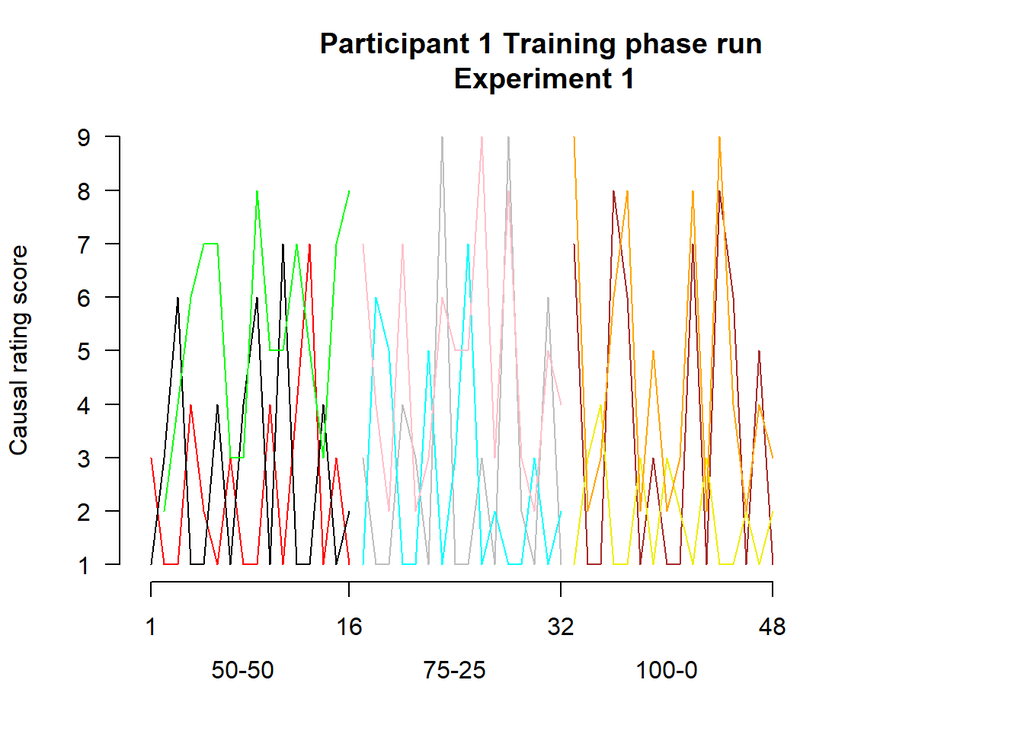

```r
#p1 had Cond 0, 50, 100
par(mfrow = c(1,1))
par(las = 1)
emptyPlot(c(1,60), c(1,9), xmark = c(1,16,32,48), ymark= c(1,2,3,4,5,6,7,8,9), bty = 'n', main = "Participant 1 Training phase run\n Experiment 1", xlab = "", ylab = "Causal rating score")
points(c(1:16), P1$responseR1[P1$blockNr == "Block1"], type = 'l', col = "red", lty = 1, lwd = 1)
points(c(1:16), P1$responseR2[P1$blockNr == "Block1"], type = 'l', col = "black", lty = 1, lwd = 1)
points(c(1:16), P1$responseR3[P1$blockNr == "Block1"], type = 'l', col = "green", lty = 1, lwd = 1)
points(c(17:32), P1$responseR1[P1$blockNr == "Block2"], type = 'l', col = "grey", lty = 1, lwd = 1)
points(c(17:32), P1$responseR2[P1$blockNr == "Block2"], type = 'l', col = "cyan", lty = 1, lwd = 1)
points(c(17:32), P1$responseR3[P1$blockNr == "Block2"], type = 'l', col = "pink", lty = 1, lwd = 1)
points(c(33:48), P1$responseR1[P1$blockNr == "Block3"], type = 'l', col = "brown", lty = 1, lwd = 1)
points(c(33:48), P1$responseR2[P1$blockNr == "Block3"], type = 'l', col = "yellow2", lty = 1, lwd = 1)
points(c(33:48), P1$responseR3[P1$blockNr == "Block3"], type = 'l', col = "orange", lty = 1, lwd = 1)
mtext("50-50", side = 1, at = 8, line = 2.5)
mtext("75-25", side = 1, at = 24, line = 2.5)
mtext("100-0", side = 1, at = 40, line = 2.5)
```

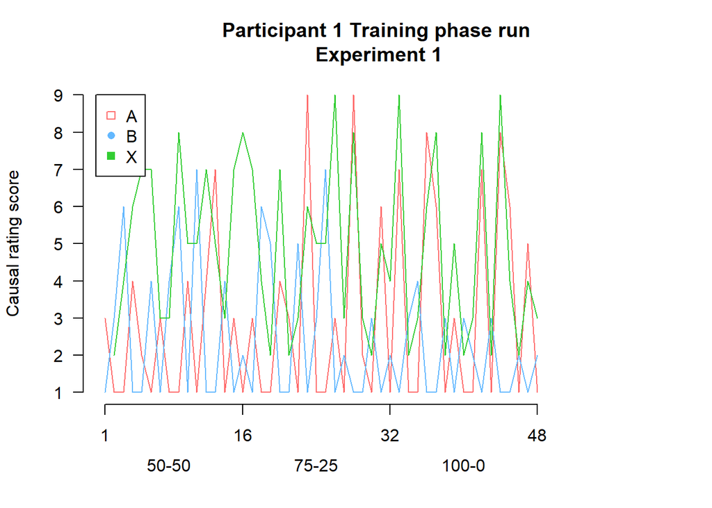

```r
#still P1
par(mfrow = c(1,1))
par(las = 1)
emptyPlot(c(1,60), c(1,9), xmark = c(1,16,32,48), ymark= c(1,2,3,4,5,6,7,8,9), bty = 'n', main = "Participant 1 Training phase run\n Experiment 1", xlab = "", ylab = "Causal rating score")
points(c(1:48), P1$responseR1, type = 'l', col = "indianred1", lty = 1, lwd = 1)
points(c(1:48), P1$responseR2, type = 'l', col = "steelblue1", lty = 1, lwd = 1)
points(c(1:48), P1$responseR3, type = 'l', col = "limegreen", lty = 1, lwd = 1)
mtext("50-50", side = 1, at = 8, line = 2.5)
mtext("75-25", side = 1, at = 24, line = 2.5)
mtext("100-0", side = 1, at = 40, line = 2.5)
legend(0.02,9,legend =c("A", "B", "X"), pch = c(0,16,15), col = c("indianred1", "steelblue1", "limegreen"))
```

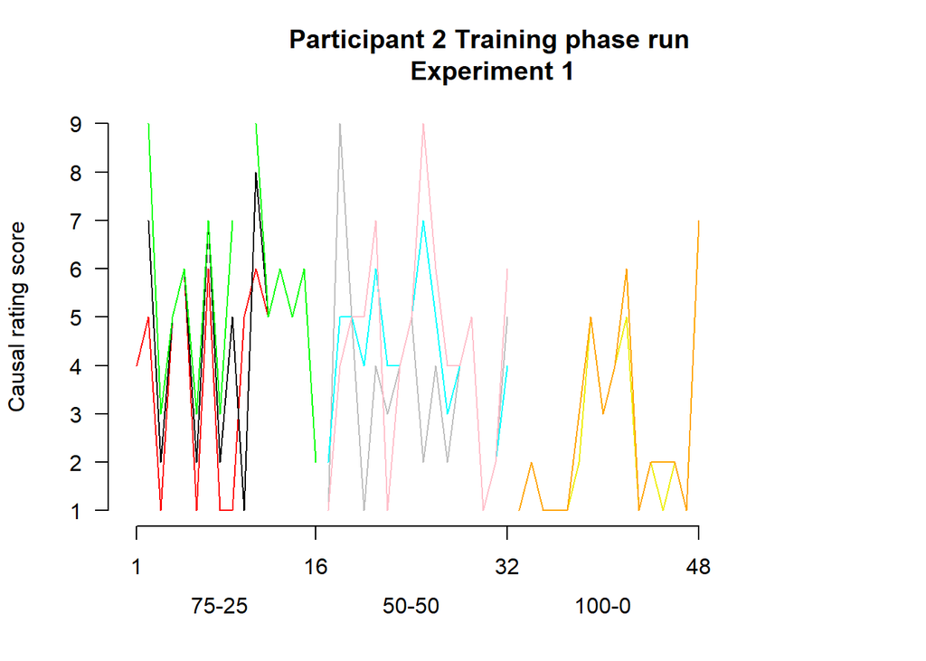

```r
#p2 had Cond 50, 0, 100.
par(mfrow = c(1,1))
par(las = 1)
emptyPlot(c(1,60), c(1,9), xmark = c(1,16,32,48), ymark= c(1,2,3,4,5,6,7,8,9), bty = 'n', main = "Participant 2 Training phase run\n Experiment 1", xlab = "", ylab = "Causal rating score")
points(c(1:16), P2$responseR1[P2$blockNr == "Block1"], type = 'l', col = "red", lty = 1, lwd = 1)
points(c(1:16), P2$responseR2[P2$blockNr == "Block1"], type = 'l', col = "black", lty = 1, lwd = 1)
points(c(1:16), P2$responseR3[P2$blockNr == "Block1"], type = 'l', col = "green", lty = 1, lwd = 1)
points(c(17:32), P2$responseR1[P2$blockNr == "Block2"], type = 'l', col = "grey", lty = 1, lwd = 1)
points(c(17:32), P2$responseR2[P2$blockNr == "Block2"], type = 'l', col = "cyan", lty = 1, lwd = 1)
points(c(17:32), P2$responseR3[P2$blockNr == "Block2"], type = 'l', col = "pink", lty = 1, lwd = 1)
points(c(33:48), P2$responseR1[P2$blockNr == "Block3"], type = 'l', col = "brown", lty = 1, lwd = 1)
points(c(33:48), P2$responseR2[P2$blockNr == "Block3"], type = 'l', col = "yellow2", lty = 1, lwd = 1)
points(c(33:48), P2$responseR3[P2$blockNr == "Block3"], type = 'l', col = "orange", lty = 1, lwd = 1)
mtext("75-25", side = 1, at = 8, line = 2.5)
mtext("50-50", side = 1, at = 24, line = 2.5)
mtext("100-0", side = 1, at = 40, line = 2.5)
```

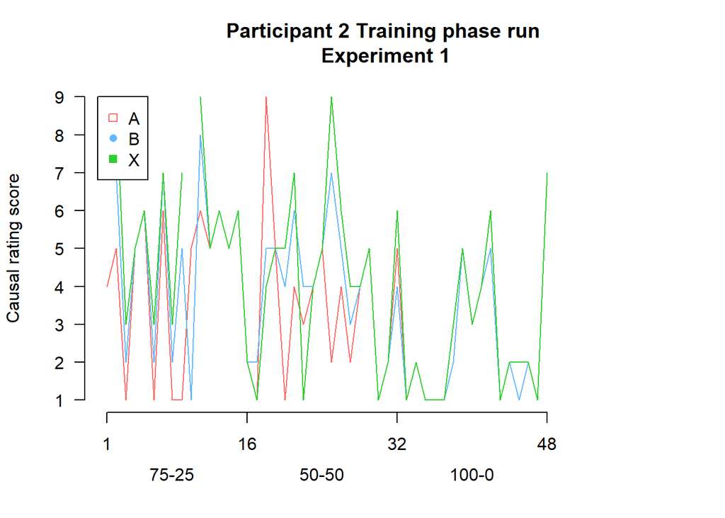

```r
#still P2
par(mfrow = c(1,1))
par(las = 1)
emptyPlot(c(1,60), c(1,9), xmark = c(1,16,32,48), ymark= c(1,2,3,4,5,6,7,8,9), bty = 'n', main = "Participant 2 Training phase run\n Experiment 1", xlab = "", ylab = "Causal rating score")
points(c(1:48), P2$responseR1, type = 'l', col = "indianred1", lty = 1, lwd = 1)
points(c(1:48), P2$responseR2, type = 'l', col = "steelblue1", lty = 1, lwd = 1)
points(c(1:48), P2$responseR3, type = 'l', col = "limegreen", lty = 1, lwd = 1)
mtext("75-25", side = 1, at = 8, line = 2.5)
mtext("50-50", side = 1, at = 24, line = 2.5)
mtext("100-0", side = 1, at = 40, line = 2.5)
legend(0.02,9,legend =c("A", "B", "X"), pch = c(0,16,15), col = c("indianred1", "steelblue1", "limegreen"))
```

Very strange. This participant seems to have big chunks of data missing (e.g look at the A line), however all that data *is* there. There are no NA’s:

```r
P2$responseR1
```

```
##  [1] 4 5 1 5 6 1 6 1 1 5 6 5 6 5 6 2 1 9 5 1 4 3 4 5 2 4 2 4 5 1 2 5 1 2 1 1 1 2
## [39] 5 3 4 5 1 2 2 2 1 7
```

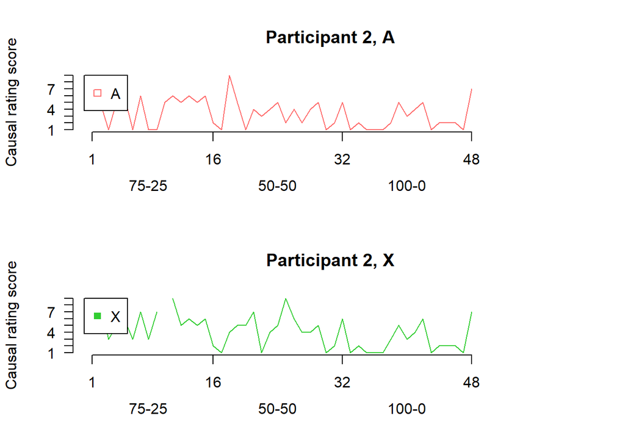

```r
par(mfrow = c(2,1))
par(las = 1)
emptyPlot(c(1,60), c(1,9), xmark = c(1,16,32,48), ymark= c(1,2,3,4,5,6,7,8,9), bty = 'n', main = "Participant 2, A", xlab = "", ylab = "Causal rating score")
points(c(1:48), P2$responseR1, type = 'l', col = "indianred1", lty = 1, lwd = 1)
mtext("75-25", side = 1, at = 8, line = 2.5)
mtext("50-50", side = 1, at = 24, line = 2.5)
mtext("100-0", side = 1, at = 40, line = 2.5)
legend(0.02,9,legend =c("A"), pch = c(0), col = c("indianred1"))

emptyPlot(c(1,60), c(1,9), xmark = c(1,16,32,48), ymark= c(1,2,3,4,5,6,7,8,9), bty = 'n', main = "Participant 2, X", xlab = "", ylab = "Causal rating score")
points(c(1:48), P2$responseR3, type = 'l', col = "limegreen", lty = 1, lwd = 1)
mtext("75-25", side = 1, at = 8, line = 2.5)
mtext("50-50", side = 1, at = 24, line = 2.5)
mtext("100-0", side = 1, at = 40, line = 2.5)
legend(0.02,9,legend =c("X"), pch = c(15), col = c("limegreen"))
```

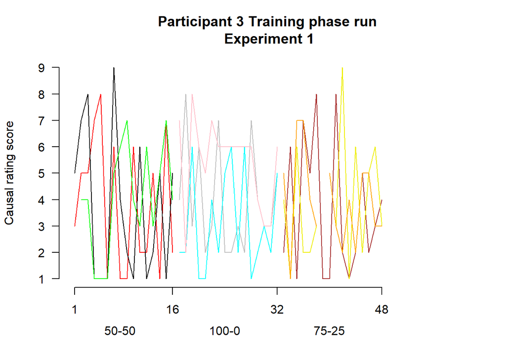

```r
#p3 had Cond 0, 100, 50.
par(mfrow = c(1,1))
par(las = 1)
emptyPlot(c(1,60), c(1,9), xmark = c(1,16,32,48), ymark= c(1,2,3,4,5,6,7,8,9), bty = 'n', main = "Participant 3 Training phase run\n Experiment 1", xlab = "", ylab = "Causal rating score")
points(c(1:16), P3$responseR1[P3$blockNr == "Block1"], type = 'l', col = "red", lty = 1, lwd = 1)
points(c(1:16), P3$responseR2[P3$blockNr == "Block1"], type = 'l', col = "black", lty = 1, lwd = 1)
points(c(1:16), P3$responseR3[P3$blockNr == "Block1"], type = 'l', col = "green", lty = 1, lwd = 1)
points(c(17:32), P3$responseR1[P3$blockNr == "Block2"], type = 'l', col = "grey", lty = 1, lwd = 1)
points(c(17:32), P3$responseR2[P3$blockNr == "Block2"], type = 'l', col = "cyan", lty = 1, lwd = 1)
points(c(17:32), P3$responseR3[P3$blockNr == "Block2"], type = 'l', col = "pink", lty = 1, lwd = 1)
points(c(33:48), P3$responseR1[P3$blockNr == "Block3"], type = 'l', col = "brown", lty = 1, lwd = 1)
points(c(33:48), P3$responseR2[P3$blockNr == "Block3"], type = 'l', col = "yellow2", lty = 1, lwd = 1)
points(c(33:48), P3$responseR3[P3$blockNr == "Block3"], type = 'l', col = "orange", lty = 1, lwd = 1)
mtext("50-50", side = 1, at = 8, line = 2.5)
mtext("100-0", side = 1, at = 24, line = 2.5)
mtext("75-25", side = 1, at = 40, line = 2.5)
```

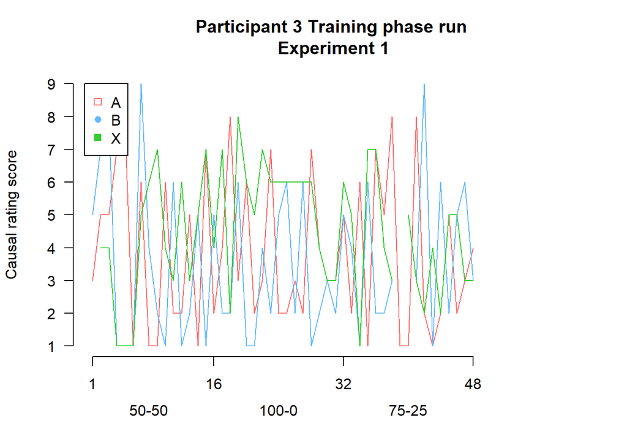

```r
#still P3
par(mfrow = c(1,1))
par(las = 1)
emptyPlot(c(1,60), c(1,9), xmark = c(1,16,32,48), ymark= c(1,2,3,4,5,6,7,8,9), bty = 'n', main = "Participant 3 Training phase run\n Experiment 1", xlab = "", ylab = "Causal rating score")
points(c(1:48), P3$responseR1, type = 'l', col = "indianred1", lty = 1, lwd = 1)
points(c(1:48), P3$responseR2, type = 'l', col = "steelblue1", lty = 1, lwd = 1)
points(c(1:48), P3$responseR3, type = 'l', col = "limegreen", lty = 1, lwd = 1)
mtext("50-50", side = 1, at = 8, line = 2.5)
mtext("100-0", side = 1, at = 24, line = 2.5)
mtext("75-25", side = 1, at = 40, line = 2.5)
legend(0.02,9,legend =c("A", "B", "X"), pch = c(0,16,15), col = c("indianred1", "steelblue1", "limegreen"))
```

## Diamond versus no Diamond trials

```r
#Calculating the average scores on the trials where "Diamond" was the outcome, and on trials where "No Diamond" was the outcome
#We would expect that the scores to the No Diamond would be lower on average
Diamond <- subset(train, train$Outcome == "Diamond.png")
NoDiamond <- subset(train, train$Outcome == "NoDiamond.png")

DiamondAvg <- aggregate(list(Diamond$responseR1, Diamond$responseR2, Diamond$responseR3), list(Diamond$Cond), mean, na.rm = T)
NoDiamondAvg <- aggregate(list(NoDiamond$responseR1, NoDiamond$responseR2, NoDiamond$responseR3), list(NoDiamond$Cond), mean, na.rm = T)
SE <- c(std.error(Diamond$responseR1[Diamond$Cond == "0"]), std.error(NoDiamond$responseR1[NoDiamond$Cond == "0"]), std.error(Diamond$responseR2[Diamond$Cond == "0"]), std.error(NoDiamond$responseR2[NoDiamond$Cond == "0"]), std.error(Diamond$responseR3[Diamond$Cond == "0"]), std.error(NoDiamond$responseR3[NoDiamond$Cond == "0"]),  std.error(Diamond$responseR1[Diamond$Cond == "50"]), std.error(NoDiamond$responseR1[NoDiamond$Cond == "50"]), std.error(Diamond$responseR2[Diamond$Cond == "50"]), std.error(NoDiamond$responseR2[NoDiamond$Cond == "50"]), std.error(Diamond$responseR3[Diamond$Cond == "50"]), std.error(NoDiamond$responseR3[NoDiamond$Cond == "50"]),  std.error(Diamond$responseR1[Diamond$Cond == "100"]), std.error(NoDiamond$responseR1[NoDiamond$Cond == "100"]), std.error(Diamond$responseR2[Diamond$Cond == "100"]), std.error(NoDiamond$responseR2[NoDiamond$Cond == "100"]), std.error(Diamond$responseR3[Diamond$Cond == "100"]), std.error(NoDiamond$responseR3[NoDiamond$Cond == "100"]))
colnames(DiamondAvg) <- c("Cond", "A", "B", "X")
colnames(NoDiamondAvg) <- c("Cond", "A", "B", "X")

DiamondAvg
```

```
##   Cond        A        B        X
## 1    0 4.514706 3.906183 5.186551
## 2   50 4.941423 3.694444 5.410753
## 3  100 5.440252 3.447983 5.221277
```

```r
NoDiamondAvg
```

```
##   Cond        A        B        X
## 1    0 4.008386 3.523305 4.576923
## 2   50 3.884696 3.459746 4.339744
## 3  100 4.010438 3.390397 4.362288
```

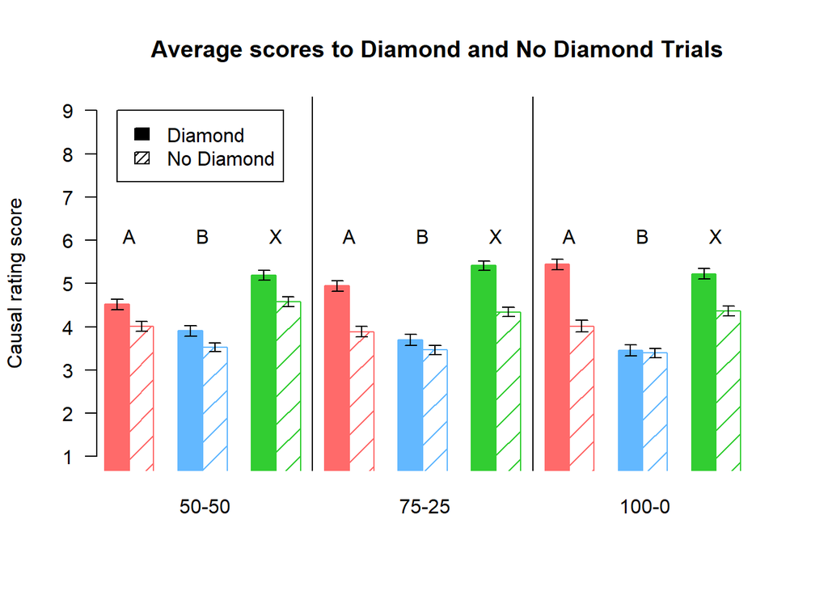

```r
par(mfrow = c(1,1))
par(las = 1)
emptyPlot(c(1,130), c(1,9), xaxt = "none", ymark= c(1,2,3,4,5,6, 7, 8,9), bty = 'n', main = "Average scores to Diamond and No Diamond Trials", xlab = "", ylab = "Causal rating score")
add_bars(x=c(0,5,15,20,30,35, 45,50,60,65,75,80, 90,95,105,110,120,125), y=c(DiamondAvg$A[DiamondAvg$Cond == "0"], NoDiamondAvg$A[NoDiamondAvg$Cond == "0"], DiamondAvg$B[DiamondAvg$Cond == "0"], NoDiamondAvg$B[NoDiamondAvg$Cond == "0"],DiamondAvg$X[DiamondAvg$Cond == "0"], NoDiamondAvg$X[NoDiamondAvg$Cond == "0"], DiamondAvg$A[DiamondAvg$Cond == "50"], NoDiamondAvg$A[NoDiamondAvg$Cond == "50"], DiamondAvg$B[DiamondAvg$Cond == "50"], NoDiamondAvg$B[NoDiamondAvg$Cond == "50"],DiamondAvg$X[DiamondAvg$Cond == "50"], NoDiamondAvg$X[NoDiamondAvg$Cond == "50"], DiamondAvg$A[DiamondAvg$Cond == "100"], NoDiamondAvg$A[NoDiamondAvg$Cond == "100"], DiamondAvg$B[DiamondAvg$Cond == "100"], NoDiamondAvg$B[NoDiamondAvg$Cond == "100"],DiamondAvg$X[DiamondAvg$Cond == "100"], NoDiamondAvg$X[NoDiamondAvg$Cond == "100"]), width = 5, col = c("indianred1", "indianred1", "steelblue1", "steelblue1", "limegreen", "limegreen"), density = c(200,6))

errorbars(x=c(0,5,15,20,30,35, 45,50,60,65,75,80, 90,95,105,110,120,125), y=c(DiamondAvg$A[DiamondAvg$Cond == "0"], NoDiamondAvg$A[NoDiamondAvg$Cond == "0"], DiamondAvg$B[DiamondAvg$Cond == "0"], NoDiamondAvg$B[NoDiamondAvg$Cond == "0"],DiamondAvg$X[DiamondAvg$Cond == "0"], NoDiamondAvg$X[NoDiamondAvg$Cond == "0"], DiamondAvg$A[DiamondAvg$Cond == "50"], NoDiamondAvg$A[NoDiamondAvg$Cond == "50"], DiamondAvg$B[DiamondAvg$Cond == "50"], NoDiamondAvg$B[NoDiamondAvg$Cond == "50"],DiamondAvg$X[DiamondAvg$Cond == "50"], NoDiamondAvg$X[NoDiamondAvg$Cond == "50"], DiamondAvg$A[DiamondAvg$Cond == "100"], NoDiamondAvg$A[NoDiamondAvg$Cond == "100"], DiamondAvg$B[DiamondAvg$Cond == "100"], NoDiamondAvg$B[NoDiamondAvg$Cond == "100"],DiamondAvg$X[DiamondAvg$Cond == "100"], NoDiamondAvg$X[NoDiamondAvg$Cond == "100"]) , top = SE , bottom = SE, add = TRUE, length = .05)

abline(v=40, col="grey2", lty = 1)
abline(v=85, col="grey2", lty = 1)
#condition text
mtext("50-50", side = 1, at = 18, line = 1)
mtext("75-25", side = 1, at = 63, line = 1)
mtext("100-0", side = 1, at = 108, line = 1)
#letters
text(x=2.5, y = 6.1, labels = "A")
text(x=47.5, y = 6.1, labels = "A")
text(x=92.5, y = 6.1, labels = "A")
text(x=17.5, y = 6.1, labels = "B")
text(x=62.5, y = 6.1, labels = "B")
text(x=107.5, y = 6.1, labels = "B")
text(x=32.5, y = 6.1, labels = "X")
text(x=77.5, y = 6.1, labels = "X")
text(x=122.5, y = 6.1, labels = "X")
legend(x=0, y = 9, legend =c("Diamond", "No Diamond"), density = c(200,20), col= c("indianred1"))
```

```r
#c("indianred1", "indianred3", "steelblue1", "steelblue3", "limegreen", "palegreen4"))

SE
```

```
##  [1] 0.1229682 0.1152526 0.1196804 0.1013987 0.1130868 0.1081903 0.1215447
##  [8] 0.1184691 0.1217807 0.1076702 0.1086401 0.1090906 0.1237582 0.1323224
## [15] 0.1258207 0.1072163 0.1185317 0.1156042
```

```r
range(SE)
```

```
## [1] 0.1013987 0.1323224
```

```r
t.test(Diamond$responseR1[Diamond$Cond == "0"], NoDiamond$responseR1[NoDiamond$Cond == "0"], alternative = "two.sided", paired = FALSE) #sign, diamond higher than not diamond
```

```
##
##  Welch Two Sample t-test
##
## data:  Diamond$responseR1[Diamond$Cond == "0"] and NoDiamond$responseR1[NoDiamond$Cond == "0"]
## t = 3.0042, df = 946.91, p-value = 0.002733
## alternative hypothesis: true difference in means is not equal to 0
## 95 percent confidence interval:
##  0.1755732 0.8370671
## sample estimates:
## mean of x mean of y
##  4.514706  4.008386
```

```r
t.test(Diamond$responseR2[Diamond$Cond == "0"], NoDiamond$responseR2[NoDiamond$Cond == "0"], alternative = "two.sided", paired = FALSE) #sign, diamond higher than not diamond
```

```
##
##  Welch Two Sample t-test
##
## data:  Diamond$responseR2[Diamond$Cond == "0"] and NoDiamond$responseR2[NoDiamond$Cond == "0"]
## t = 2.4409, df = 913.39, p-value = 0.01484
## alternative hypothesis: true difference in means is not equal to 0
## 95 percent confidence interval:
##  0.07503018 0.69072638
## sample estimates:
## mean of x mean of y
##  3.906183  3.523305
```

```r
t.test(Diamond$responseR3[Diamond$Cond == "0"], NoDiamond$responseR3[NoDiamond$Cond == "0"], alternative = "two.sided", paired = FALSE) #sign, diamond higher than not diamond
```

```
##
##  Welch Two Sample t-test
##
## data:  Diamond$responseR3[Diamond$Cond == "0"] and NoDiamond$responseR3[NoDiamond$Cond == "0"]
## t = 3.8953, df = 924.52, p-value = 0.0001052
## alternative hypothesis: true difference in means is not equal to 0
## 95 percent confidence interval:
##  0.3024819 0.9167739
## sample estimates:
## mean of x mean of y
##  5.186551  4.576923
```

```r
t.test(Diamond$responseR1[Diamond$Cond == "50"], NoDiamond$responseR1[NoDiamond$Cond == "50"], alternative = "two.sided", paired = FALSE) #sign, diamond higher than not diamond
```

```
##
##  Welch Two Sample t-test
##
## data:  Diamond$responseR1[Diamond$Cond == "50"] and NoDiamond$responseR1[NoDiamond$Cond == "50"]
## t = 6.226, df = 952.42, p-value = 7.167e-10
## alternative hypothesis: true difference in means is not equal to 0
## 95 percent confidence interval:
##  0.7236399 1.3898132
## sample estimates:
## mean of x mean of y
##  4.941423  3.884696
```

```r
t.test(Diamond$responseR2[Diamond$Cond == "50"], NoDiamond$responseR2[NoDiamond$Cond == "50"], alternative = "two.sided", paired = FALSE) #not sign
```

```
##
##  Welch Two Sample t-test
##
## data:  Diamond$responseR2[Diamond$Cond == "50"] and NoDiamond$responseR2[NoDiamond$Cond == "50"]
## t = 1.4438, df = 923.16, p-value = 0.1491
## alternative hypothesis: true difference in means is not equal to 0
## 95 percent confidence interval:
##  -0.08431728  0.55371464
## sample estimates:
## mean of x mean of y
##  3.694444  3.459746
```

```r
t.test(Diamond$responseR3[Diamond$Cond == "50"], NoDiamond$responseR3[NoDiamond$Cond == "50"], alternative = "two.sided", paired = FALSE) #sign, diamond higher than not diamond
```

```
##
##  Welch Two Sample t-test
##
## data:  Diamond$responseR3[Diamond$Cond == "50"] and NoDiamond$responseR3[NoDiamond$Cond == "50"]
## t = 6.9564, df = 931, p-value = 6.572e-12
## alternative hypothesis: true difference in means is not equal to 0
## 95 percent confidence interval:
##  0.7688618 1.3731564
## sample estimates:
## mean of x mean of y
##  5.410753  4.339744
```

```r
t.test(Diamond$responseR1[Diamond$Cond == "100"], NoDiamond$responseR1[NoDiamond$Cond == "100"], alternative = "two.sided", paired = FALSE) #sign, diamond higher than not diamond
```

```
##
##  Welch Two Sample t-test
##
## data:  Diamond$responseR1[Diamond$Cond == "100"] and NoDiamond$responseR1[NoDiamond$Cond == "100"]
## t = 7.8918, df = 950.02, p-value = 8.177e-15
## alternative hypothesis: true difference in means is not equal to 0
## 95 percent confidence interval:
##  1.074259 1.785368
## sample estimates:
## mean of x mean of y
##  5.440252  4.010438
```

```r
t.test(Diamond$responseR2[Diamond$Cond == "100"], NoDiamond$responseR2[NoDiamond$Cond == "100"], alternative = "two.sided", paired = FALSE) #not sign
```

```
##
##  Welch Two Sample t-test
##
## data:  Diamond$responseR2[Diamond$Cond == "100"] and NoDiamond$responseR2[NoDiamond$Cond == "100"]
## t = 0.34836, df = 922.25, p-value = 0.7276
## alternative hypothesis: true difference in means is not equal to 0
## 95 percent confidence interval:
##  -0.2668339  0.3820066
## sample estimates:
## mean of x mean of y
##  3.447983  3.390397
```

```r
t.test(Diamond$responseR3[Diamond$Cond == "100"], NoDiamond$responseR3[NoDiamond$Cond == "100"], alternative = "two.sided", paired = FALSE) #sign, diamond higher than not diamond
```

```
##
##  Welch Two Sample t-test
##
## data:  Diamond$responseR3[Diamond$Cond == "100"] and NoDiamond$responseR3[NoDiamond$Cond == "100"]
## t = 5.188, df = 939.31, p-value = 2.604e-07
## alternative hypothesis: true difference in means is not equal to 0
## 95 percent confidence interval:
##  0.5340547 1.1839222
## sample estimates:
## mean of x mean of y
##  5.221277  4.362288
```

These t-test show exactly what we would expect. The diamond trials are always scored higher than the no diamond trials. That is except for B. This makes sense though, because, except for the 50-50 condition, B predicts an diamond outcome a lot less than the others. So here we would expect that people will start to score B lower overall, even on the trials where it does predict an allergic reaction.

# TEST PHASE

```r
#First getting the test phase data
test <- dat[which(dat$Train_Test == "Test"),]
test$responseR1[test$responseR1 == 999] <- NA
test$responseR2[test$responseR2 == 999] <- NA
test$responseR3[test$responseR3 == 999] <- NA

#And also splitting them into the different phases
testP1 <- test[which(test$Cond == "Phase1"),]
testP2 <- test[which(test$Cond == "Phase2"),]
testP3 <- test[which(test$Cond == "Phase3"),]
testP12 <- test[which(test$Cond == "Phase1" | test$Cond == "Phase2"),]
```

## Phase 1

This phase was in the same order for each participant. At first the cues from the first block were seen, then a new cue (together with X of the first block) and then those of the third block were seen. This time participants were asked how likely they thought these items would lead to outcome Y, with Y being either a diamond (which they’ve seen before) or a fossil (a new outcome)

### Creating and preparing the data

```r
#Phase 1

#I want to look at the outcome to fossil and that to diamond
testF <- testP1[which(testP1$Outcome == "Fossil.png"),]
testD <- testP1[which(testP1$Outcome == "Diamond.png"),]

#Now I want the average scores for A B and X for each of these outcomes, but also specifically A1, B1 etc. Therefore I will have to look at specific responses to trials. Therefore aggregate isn't very useful to use here.

#X
X1F <- testF[which(testF$Trial == 2 | testF$Trial == 4 | testF$Trial == 6),]
avgX1F <- mean(X1F$responseR2, na.rm = T)
X1D <- testD[which(testD$Trial == 1 | testD$Trial == 3 | testD$Trial == 5),]
avgX1D <- mean(X1D$responseR2, na.rm = T)
X3F <- testF[which(testF$Trial == 8 | testF$Trial == 10),]
avgX3F <- mean(X3F$responseR2, na.rm = T)
X3D <- testD[which(testD$Trial == 7 | testD$Trial == 9),]
avgX3D <- mean(X3D$responseR2, na.rm = T)

#A
A1F <- testF[which(testF$Trial == 2),]
avgA1F <- mean(A1F$responseR1, na.rm = T)
A1D <- testD[which(testD$Trial == 1),]
avgA1D <- mean(A1D$responseR1, na.rm = T)

A3F <- testF[which(testF$Trial == 8),]
avgA3F <- mean(A3F$responseR1, na.rm = T)
A3D <- testD[which(testD$Trial == 7),]
avgA3D <- mean(A3D$responseR1, na.rm = T)

#B
B1F <- testF[which(testF$Trial == 4),]
avgB1F <- mean(B1F$responseR1, na.rm = T)
B1D <- testD[which(testD$Trial == 3),]
avgB1D <- mean(B1D$responseR1, na.rm = T)

B3F <- testF[which(testF$Trial == 10),]
avgB3F <- mean(B3F$responseR1, na.rm = T)
B3D <- testD[which(testD$Trial == 9),]
avgB3D <- mean(B3D$responseR1, na.rm = T)

#C
CF <- testF[which(testF$Trial == 6),]
avgCF <- mean(CF$responseR1, na.rm = T)
CD <- testD[which(testD$Trial == 5),]
avgCD <- mean(CD$responseR1, na.rm = T)


Cue <- c("A1", "B1", "X1", "C", "A3", "B3", "X3")
Diamond <- c(avgA1D, avgB1D, avgX1D, avgCD, avgA3D, avgB3D, avgX3D)
Fossil <- c(avgA1F, avgB1F, avgX1F, avgCF, avgA3F, avgB3F, avgX3F)
Phase1 <- data.frame(Cue, Diamond, Fossil)
Phase1
```

```
##   Cue  Diamond   Fossil
## 1  A1 4.372881 3.728814
## 2  B1 4.847458 3.440678
## 3  X1 5.248588 4.581921
## 4   C 3.627119 3.850000
## 5  A3 6.066667 4.100000
## 6  B3 3.116667 4.083333
## 7  X3 4.991667 4.658333
```

```r
#now that we know what was asked when in the training phase

ABl1 <- mean(train$responseR1[train$blockNr == "Block1" & train$Trial == 16], na.rm = T)
BBl1 <- mean(train$responseR2[train$blockNr == "Block1" & train$Trial == 16], na.rm = T)
XBl1 <- mean(train$responseR3[train$blockNr == "Block1" & train$Trial == 16], na.rm = T)

ABl3 <- mean(train$responseR1[train$blockNr == "Block3" & train$Trial == 16], na.rm = T)
BBl3 <- mean(train$responseR2[train$blockNr == "Block3" & train$Trial == 16], na.rm = T)
XBl3 <- mean(train$responseR3[train$blockNr == "Block3" & train$Trial == 16], na.rm = T)

Cues <- c("A1", "B1", "X1", "A3", "B3", "X3")
Mean <- c(ABl1, BBl1, XBl1, ABl3, BBl3, XBl3)
TrainAvgBl1_3 <- data.frame(Cues, Mean)
TrainAvgBl1_3
```

```
##   Cues     Mean
## 1   A1 4.288136
## 2   B1 3.745763
## 3   X1 4.534483
## 4   A3 3.666667
## 5   B3 3.322034
## 6   X3 4.305085
```

```r
Original <- c(ABl1, BBl1, XBl1, "NA", ABl3, BBl3, XBl3)
Phase1$Original <- as.numeric(Original)
Phase1
```

```
##   Cue  Diamond   Fossil Original
## 1  A1 4.372881 3.728814 4.288136
## 2  B1 4.847458 3.440678 3.745763
## 3  X1 5.248588 4.581921 4.534483
## 4   C 3.627119 3.850000       NA
## 5  A3 6.066667 4.100000 3.666667
## 6  B3 3.116667 4.083333 3.322034
## 7  X3 4.991667 4.658333 4.305085
```

Here we can see the differences in scores to diamond in the test phase (1), fossil (test phase 1) and the original scores to A, B and X in block 1 and 3. This is averaged over all conditions. We will now perform t-tests to see if there is a difference between these values.

```r
#for just the last block to compare it to
#1) Are there significant differences between A, B and X when asked in their original block 1 and in the test phase
t.test(A1D$responseR1, train$responseR1[train$blockNr == "Block1" & train$Trial == 16], alternative = "two.sided", paired = FALSE) #no sign
```

```
##
##  Welch Two Sample t-test
##
## data:  A1D$responseR1 and train$responseR1[train$blockNr == "Block1" & train$Trial == 16]
## t = 0.17572, df = 104.16, p-value = 0.8609
## alternative hypothesis: true difference in means is not equal to 0
## 95 percent confidence interval:
##  -0.871593  1.041084
## sample estimates:
## mean of x mean of y
##  4.372881  4.288136
```

```r
t.test(B1D$responseR1, train$responseR2[train$blockNr == "Block1" & train$Trial == 16], alternative = "two.sided", paired = FALSE) #sign diff, increase
```

```
##
##  Welch Two Sample t-test
##
## data:  B1D$responseR1 and train$responseR2[train$blockNr == "Block1" & train$Trial == 16]
## t = 2.4556, df = 115.96, p-value = 0.01555
## alternative hypothesis: true difference in means is not equal to 0
## 95 percent confidence interval:
##  0.2130769 1.9903129
## sample estimates:
## mean of x mean of y
##  4.847458  3.745763
```

```r
t.test(X1D$responseR2, train$responseR3[train$blockNr == "Block1" & train$Trial == 16], alternative = "two.sided", paired = FALSE) #sign diff, increase
```

```
##
##  Welch Two Sample t-test
##
## data:  X1D$responseR2 and train$responseR3[train$blockNr == "Block1" & train$Trial == 16]
## t = 2.0063, df = 87.585, p-value = 0.0479
## alternative hypothesis: true difference in means is not equal to 0
## 95 percent confidence interval:
##  0.00673683 1.42147279
## sample estimates:
## mean of x mean of y
##  5.248588  4.534483
```

```r
#2) Are there sign differences between A, B and X when asked in block 3 and in the test phase
t.test(A3D$responseR1, train$responseR1[train$blockNr == "Block3" & train$Trial == 16], alternative = "two.sided", paired = FALSE) #sign diff, increase
```

```
##
##  Welch Two Sample t-test
##
## data:  A3D$responseR1 and train$responseR1[train$blockNr == "Block3" & train$Trial == 16]
## t = 4.5871, df = 117.38, p-value = 1.133e-05
## alternative hypothesis: true difference in means is not equal to 0
## 95 percent confidence interval:
##  1.363847 3.436153
## sample estimates:
## mean of x mean of y
##  6.066667  3.666667
```

```r
t.test(B3D$responseR1, train$responseR2[train$blockNr == "Block3" & train$Trial == 16], alternative = "two.sided", paired = FALSE) #no diff
```

```
##
##  Welch Two Sample t-test
##
## data:  B3D$responseR1 and train$responseR2[train$blockNr == "Block3" & train$Trial == 16]
## t = -0.50578, df = 115.62, p-value = 0.614
## alternative hypothesis: true difference in means is not equal to 0
## 95 percent confidence interval:
##  -1.0096169  0.5988824
## sample estimates:
## mean of x mean of y
##  3.116667  3.322034
```

```r
t.test(X3D$responseR2, train$responseR3[train$blockNr == "Block3" & train$Trial == 16], alternative = "two.sided", paired = FALSE) #no diff
```

```
##
##  Welch Two Sample t-test
##
## data:  X3D$responseR2 and train$responseR3[train$blockNr == "Block3" & train$Trial == 16]
## t = 1.8084, df = 120.34, p-value = 0.07305
## alternative hypothesis: true difference in means is not equal to 0
## 95 percent confidence interval:
##  -0.06512032  1.43828416
## sample estimates:
## mean of x mean of y
##  4.991667  4.305085
```

```r
#there is a significant difference for 2/3 cues in the first block. This would be according to the van hamme wasserman paper, and as there are less differences in the third block, this would still be in line with van hamme and wasserman.


#3) Is there a sign difference between the C value and that of A B and X in the test phase
t.test(CD$responseR1, A3D$responseR1, alternative = "two.sided", paired = FALSE) #diff, lower C
```

```
##
##  Welch Two Sample t-test
##
## data:  CD$responseR1 and A3D$responseR1
## t = -4.8266, df = 114.72, p-value = 4.318e-06
## alternative hypothesis: true difference in means is not equal to 0
## 95 percent confidence interval:
##  -3.440746 -1.438350
## sample estimates:
## mean of x mean of y
##  3.627119  6.066667
```

```r
t.test(CD$responseR1, B3D$responseR1, alternative = "two.sided", paired = FALSE) #no sign diff
```

```
##
##  Welch Two Sample t-test
##
## data:  CD$responseR1 and B3D$responseR1
## t = 1.1392, df = 116.04, p-value = 0.257
## alternative hypothesis: true difference in means is not equal to 0
## 95 percent confidence interval:
##  -0.3770574  1.3979614
## sample estimates:
## mean of x mean of y
##  3.627119  3.116667
```

```r
t.test(CD$responseR1, X3D$responseR2, alternative = "two.sided", paired = FALSE) #diff, lower C
```

```
##
##  Welch Two Sample t-test
##
## data:  CD$responseR1 and X3D$responseR2
## t = -3.4206, df = 112.58, p-value = 0.0008714
## alternative hypothesis: true difference in means is not equal to 0
## 95 percent confidence interval:
##  -2.1549157 -0.5741803
## sample estimates:
## mean of x mean of y
##  3.627119  4.991667
```

```r
t.test(CD$responseR1, A1D$responseR1, alternative = "two.sided", paired = FALSE) #no diff
```

```
##
##  Welch Two Sample t-test
##
## data:  CD$responseR1 and A1D$responseR1
## t = -1.7304, df = 112.74, p-value = 0.08629
## alternative hypothesis: true difference in means is not equal to 0
## 95 percent confidence interval:
##  -1.5996180  0.1080926
## sample estimates:
## mean of x mean of y
##  3.627119  4.372881
```

```r
t.test(CD$responseR1, B1D$responseR1, alternative = "two.sided", paired = FALSE) #diff lower C
```

```
##
##  Welch Two Sample t-test
##
## data:  CD$responseR1 and B1D$responseR1
## t = -2.6802, df = 115.73, p-value = 0.008431
## alternative hypothesis: true difference in means is not equal to 0
## 95 percent confidence interval:
##  -2.1221716 -0.3185063
## sample estimates:
## mean of x mean of y
##  3.627119  4.847458
```

```r
t.test(CD$responseR1, X1D$responseR2, alternative = "two.sided", paired = FALSE) #diff lower C
```

```
##
##  Welch Two Sample t-test
##
## data:  CD$responseR1 and X1D$responseR2
## t = -4.4267, df = 86.87, p-value = 2.769e-05
## alternative hypothesis: true difference in means is not equal to 0
## 95 percent confidence interval:
##  -2.3495324 -0.8934055
## sample estimates:
## mean of x mean of y
##  3.627119  5.248588
```

```r
#4) Is there a difference between the ratings to fossil and those to diamond?
t.test(A1D$responseR1, A1F$responseR1, alternative = "two.sided", paired = FALSE) #not sign
```

```
##
##  Welch Two Sample t-test
##
## data:  A1D$responseR1 and A1F$responseR1
## t = 1.5598, df = 114.95, p-value = 0.1216
## alternative hypothesis: true difference in means is not equal to 0
## 95 percent confidence interval:
##  -0.1738489  1.4619845
## sample estimates:
## mean of x mean of y
##  4.372881  3.728814
```

```r
t.test(B1D$responseR1, B1F$responseR1, alternative = "two.sided", paired = FALSE) #sign, lower score on the fossil than on the diamond
```

```
##
##  Welch Two Sample t-test
##
## data:  B1D$responseR1 and B1F$responseR1
## t = 3.2992, df = 115.16, p-value = 0.001291
## alternative hypothesis: true difference in means is not equal to 0
## 95 percent confidence interval:
##  0.5621815 2.2513779
## sample estimates:
## mean of x mean of y
##  4.847458  3.440678
```

```r
t.test(X1D$responseR2, X1F$responseR2, alternative = "two.sided", paired = FALSE) #sign, lower score on the fossil than on the diamond
```

```
##
##  Welch Two Sample t-test
##
## data:  X1D$responseR2 and X1F$responseR2
## t = 2.7356, df = 345.18, p-value = 0.006549
## alternative hypothesis: true difference in means is not equal to 0
## 95 percent confidence interval:
##  0.1873407 1.1459927
## sample estimates:
## mean of x mean of y
##  5.248588  4.581921
```

```r
t.test(CD$responseR1, CF$responseR1, alternative = "two.sided", paired = FALSE)   #no sign (makes sense! The cue is new)
```

```
##
##  Welch Two Sample t-test
##
## data:  CD$responseR1 and CF$responseR1
## t = -0.48158, df = 116.94, p-value = 0.631
## alternative hypothesis: true difference in means is not equal to 0
## 95 percent confidence interval:
##  -1.1394717  0.6937089
## sample estimates:
## mean of x mean of y
##  3.627119  3.850000
```

```r
t.test(A3D$responseR1, A3F$responseR1, alternative = "two.sided", paired = FALSE) #sign, lower score on the fossil than on the diamond
```

```
##
##  Welch Two Sample t-test
##
## data:  A3D$responseR1 and A3F$responseR1
## t = 3.8061, df = 116.84, p-value = 0.0002263
## alternative hypothesis: true difference in means is not equal to 0
## 95 percent confidence interval:
##  0.9433392 2.9899941
## sample estimates:
## mean of x mean of y
##  6.066667  4.100000
```

```r
t.test(B3D$responseR1, B3F$responseR1, alternative = "two.sided", paired = FALSE) #sign, higher score on fossil than on diamond
```

```
##
##  Welch Two Sample t-test
##
## data:  B3D$responseR1 and B3F$responseR1
## t = -2.1218, df = 116.53, p-value = 0.03597
## alternative hypothesis: true difference in means is not equal to 0
## 95 percent confidence interval:
##  -1.86897419 -0.06435915
## sample estimates:
## mean of x mean of y
##  3.116667  4.083333
```

```r
t.test(X3D$responseR2, X3F$responseR2, alternative = "two.sided", paired = FALSE) #not sign
```

```
##
##  Welch Two Sample t-test
##
## data:  X3D$responseR2 and X3F$responseR2
## t = 1.0389, df = 237.91, p-value = 0.2999
## alternative hypothesis: true difference in means is not equal to 0
## 95 percent confidence interval:
##  -0.2987219  0.9653886
## sample estimates:
## mean of x mean of y
##  4.991667  4.658333
```

```r
##OLD#########################


#1) Are there significant differences between A, B and X when asked in their original block 1 and in the test phase
#t.test(A1D$responseR1, train$responseR1[train$blockNr == "Block1"], alternative = "two.sided", paired = FALSE) #no sign
#t.test(B1D$responseR1, train$responseR2[train$blockNr == "Block1"], alternative = "two.sided", paired = FALSE) #sign diff, increase
#t.test(X1D$responseR2, train$responseR3[train$blockNr == "Block1"], alternative = "two.sided", paired = FALSE) #sign diff, increase


#2) Are there sign differences between A, B and X when asked in block 3 and in the test phase
#t.test(A3D$responseR1, train$responseR1[train$blockNr == "Block3"], alternative = "two.sided", paired = FALSE) #sign diff, increase
#t.test(B3D$responseR1, train$responseR2[train$blockNr == "Block3"], alternative = "two.sided", paired = FALSE) #no diff
#t.test(X3D$responseR2, train$responseR3[train$blockNr == "Block3"], alternative = "two.sided", paired = FALSE) #no diff

#there is a significant difference for 2/3 cues in the first block. This would be according to the van hamme wasserman paper, and as there are less differences in the third block, this would still be in line with van hamme and wasserman.


#3) Is there a sign difference between the C value and that of A B and X in the test phase
#t.test(CD$responseR1, train$responseR1[train$blockNr == "Block3"], alternative = "two.sided", paired = FALSE) #sign diff, score to C is lower
#t.test(CD$responseR1, train$responseR2[train$blockNr == "Block3"], alternative = "two.sided", paired = FALSE) #no sign diff
#t.test(CD$responseR1, train$responseR3[train$blockNr == "Block3"], alternative = "two.sided", paired = FALSE) #sign diff, score to C is lower


#t.test(CD$responseR1, train$responseR1[train$blockNr == "Block1"], alternative = "two.sided", paired = FALSE) #sign diff, score to C is lower
#t.test(CD$responseR1, train$responseR2[train$blockNr == "Block1"], alternative = "two.sided", paired = FALSE) #no sign diff
#t.test(CD$responseR1, train$responseR3[train$blockNr == "Block1"], alternative = "two.sided", paired = FALSE) #sign diff, score to C is lower

#this seems to indicate that the rescorla-wagner model is going on, as most score higher than the neutral cue, while the others are not different.


#4) Is there a difference between the ratings to fossil and those to diamond?
#t.test(A1D$responseR1, A1F$responseR1, alternative = "two.sided", paired = FALSE) #not sign
#t.test(B1D$responseR1, B1F$responseR1, alternative = "two.sided", paired = FALSE) #sign, lower score on the fossil than on the diamond
#t.test(X1D$responseR2, X1F$responseR2, alternative = "two.sided", paired = FALSE) #sign, lower score on the fossil than on the diamond
#t.test(CD$responseR1, CF$responseR1, alternative = "two.sided", paired = FALSE)   #no sign (makes sense! The cue is new)
#t.test(A3D$responseR1, A3F$responseR1, alternative = "two.sided", paired = FALSE) #sign, lower score on the fossil than on the diamond
#t.test(B3D$responseR1, B3F$responseR1, alternative = "two.sided", paired = FALSE) #sign, higher score on fossil than on diamond
#t.test(X3D$responseR2, X3F$responseR2, alternative = "two.sided", paired = FALSE) #not sign
#okay so for this it seems that especially in the block that was the furthest away, a new outcome is scored much lower than the already seen one. As for a completely new cue there is no difference between a new or an old outcome.
#for cues that were seen more recently it seems that a new outcome has less of an influence in scoring
```

What I now want to do is split this into the seperate conditions

```r
#testFSplit <- aggregate(list(testF$responseR1, testF$responseR2), list(testF$CondFirstBlock, testF$CondThirdBlock, testF$Trial), mean, na.rm = T)
#colnames(testFSplit) <- c("Cond1", "Cond3", "Trial", "Response1", "Response2")
#testDSplit <- aggregate(list(testD$responseR1, testD$responseR2), list(testD$CondFirstBlock, testD$CondThirdBlock, testD$Trial), mean, na.rm = T)
#colnames(testDSplit) <- c("Cond1", "Cond3", "Trial", "Response1", "Response2")

#for each item we want the trials that belong to the first or third cue, and then take those purely from one condition

#X000
X1F000 <- testF[which( (testF$Trial == 2 | testF$Trial == 4 | testF$Trial == 6) & testF$CondFirstBlock == "0") ,]
avgX1F000 <- mean(X1F000$responseR2, na.rm = T)
X1D000 <- testD[which( (testD$Trial == 1 | testD$Trial == 3 | testD$Trial == 5) & testD$CondFirstBlock == "0") ,]
avgX1D000 <- mean(X1D000$responseR2, na.rm = T)

X3F000 <- testF[which( (testF$Trial == 8 | testF$Trial == 10) & testF$CondThirdBlock == "0"),]
avgX3F000 <- mean(X3F000$responseR2, na.rm = T)
X3D000 <- testD[which( (testD$Trial == 7 | testD$Trial == 9) & testD$CondThirdBlock == "0"),]
avgX3D000 <- mean(X3D000$responseR2, na.rm = T)

#X050
X1F050 <- testF[which( (testF$Trial == 2 | testF$Trial == 4 | testF$Trial == 6) & testF$CondFirstBlock == "50") ,]
avgX1F050 <- mean(X1F050$responseR2, na.rm = T)
X1D050 <- testD[which( (testD$Trial == 1 | testD$Trial == 3 | testD$Trial == 5) & testD$CondFirstBlock == "50") ,]
avgX1D050 <- mean(X1D050$responseR2, na.rm = T)

X3F050 <- testF[which( (testF$Trial == 8 | testF$Trial == 10) & testF$CondThirdBlock == "50"),]
avgX3F050 <- mean(X3F050$responseR2, na.rm = T)
X3D050 <- testD[which( (testD$Trial == 7 | testD$Trial == 9) & testD$CondThirdBlock == "50"),]
avgX3D050 <- mean(X3D050$responseR2, na.rm = T)

#X100
X1F100 <- testF[which( (testF$Trial == 2 | testF$Trial == 4 | testF$Trial == 6) & testF$CondFirstBlock == "100") ,]
avgX1F100 <- mean(X1F100$responseR2, na.rm = T)
X1D100 <- testD[which( (testD$Trial == 1 | testD$Trial == 3 | testD$Trial == 5) & testD$CondFirstBlock == "100") ,]
avgX1D100 <- mean(X1D100$responseR2, na.rm = T)

X3F100 <- testF[which( (testF$Trial == 8 | testF$Trial == 10) & testF$CondThirdBlock == "100"),]
avgX3F100 <- mean(X3F100$responseR2, na.rm = T)
X3D100 <- testD[which( (testD$Trial == 7 | testD$Trial == 9) & testD$CondThirdBlock == "100"),]
avgX3D100 <- mean(X3D100$responseR2, na.rm = T)

#######################################
#A000
A1F000 <- testF[which( (testF$Trial == 2 ) & testF$CondFirstBlock == "0") ,]
avgA1F000 <- mean(A1F000$responseR1, na.rm = T)
A1D000 <- testD[which( (testD$Trial == 1) & testD$CondFirstBlock == "0") ,]
avgA1D000 <- mean(A1D000$responseR1, na.rm = T)

A3F000 <- testF[which( (testF$Trial == 8) & testF$CondThirdBlock == "0"),]
avgA3F000 <- mean(A3F000$responseR1, na.rm = T)
A3D000 <- testD[which( (testD$Trial == 7) & testD$CondThirdBlock == "0"),]
avgA3D000 <- mean(A3D000$responseR1, na.rm = T)

#A050
A1F050 <- testF[which( (testF$Trial == 2) & testF$CondFirstBlock == "50") ,]
avgA1F050 <- mean(A1F050$responseR1, na.rm = T)
A1D050 <- testD[which( (testD$Trial == 1) & testD$CondFirstBlock == "50") ,]
avgA1D050 <- mean(A1D050$responseR1, na.rm = T)

A3F050 <- testF[which( (testF$Trial == 8) & testF$CondThirdBlock == "50"),]
avgA3F050 <- mean(A3F050$responseR1, na.rm = T)
A3D050 <- testD[which( (testD$Trial == 7) & testD$CondThirdBlock == "50"),]
avgA3D050 <- mean(A3D050$responseR1, na.rm = T)

#A100
A1F100 <- testF[which( (testF$Trial == 2) & testF$CondFirstBlock == "100") ,]
avgA1F100 <- mean(A1F100$responseR1, na.rm = T)
A1D100 <- testD[which( (testD$Trial == 1) & testD$CondFirstBlock == "100") ,]
avgA1D100 <- mean(A1D100$responseR1, na.rm = T)

A3F100 <- testF[which( (testF$Trial == 8) & testF$CondThirdBlock == "100"),]
avgA3F100 <- mean(A3F100$responseR1, na.rm = T)
A3D100 <- testD[which( (testD$Trial == 7) & testD$CondThirdBlock == "100"),]
avgA3D100 <- mean(A3D100$responseR1, na.rm = T)

#######################################

#B000
B1F000 <- testF[which( (testF$Trial == 4) & testF$CondFirstBlock == "0") ,]
avgB1F000 <- mean(B1F000$responseR1, na.rm = T)
B1D000 <- testD[which( (testD$Trial == 3) & testD$CondFirstBlock == "0") ,]
avgB1D000 <- mean(B1D000$responseR1, na.rm = T)

B3F000 <- testF[which( (testF$Trial == 10) & testF$CondThirdBlock == "0"),]
avgB3F000 <- mean(B3F000$responseR1, na.rm = T)
B3D000 <- testD[which( (testD$Trial == 9) & testD$CondThirdBlock == "0"),]
avgB3D000 <- mean(B3D000$responseR1, na.rm = T)

#B050
B1F050 <- testF[which( (testF$Trial == 4) & testF$CondFirstBlock == "50") ,]
avgB1F050 <- mean(B1F050$responseR1, na.rm = T)
B1D050 <- testD[which( (testD$Trial == 3) & testD$CondFirstBlock == "50") ,]
avgB1D050 <- mean(B1D050$responseR1, na.rm = T)

B3F050 <- testF[which( (testF$Trial == 10) & testF$CondThirdBlock == "50"),]
avgB3F050 <- mean(B3F050$responseR1, na.rm = T)
B3D050 <- testD[which( (testD$Trial == 9) & testD$CondThirdBlock == "50"),]
avgB3D050 <- mean(B3D050$responseR1, na.rm = T)

#B100
B1F100 <- testF[which( (testF$Trial == 4) & testF$CondFirstBlock == "100") ,]
avgB1F100 <- mean(B1F100$responseR1, na.rm = T)
B1D100 <- testD[which( (testD$Trial == 3) & testD$CondFirstBlock == "100") ,]
avgB1D100 <- mean(B1D100$responseR1, na.rm = T)

B3F100 <- testF[which( (testF$Trial == 10) & testF$CondThirdBlock == "100"),]
avgB3F100 <- mean(B3F100$responseR1, na.rm = T)
B3D100 <- testD[which( (testD$Trial == 9) & testD$CondThirdBlock == "100"),]
avgB3D100 <- mean(B3D100$responseR1, na.rm = T)


#as C was never asked before we cannot really compare it over conditions
#C
CF <- testF[which(testF$Trial == 6),]
avgCF <- mean(CF$responseR1, na.rm = T)
CD <- testD[which(testD$Trial == 5),]
avgCD <- mean(CD$responseR1, na.rm = T)


Cue <- c("A1","A1","A1", "B1", "B1", "B1", "X1", "X1", "X1", "C", "A3", "A3", "A3", "B3", "B3", "B3", "X3", "X3", "X3")
Cond <- c("0", "50", "100", "0", "50", "100", "0", "50", "100", "NA", "0", "50", "100", "0", "50", "100", "0", "50", "100")
Diamond1 <- c(avgA1D000, avgA1D050, avgA1D100, avgB1D000, avgB1D050, avgB1D100, avgX1D000, avgX1D050, avgX1D100, avgCD, avgA3D000, avgA3D050, avgA3D100, avgB3D000, avgB3D050, avgB3D100, avgX3D000, avgX3D050, avgX3D100)
Fossil1 <- c(avgA1F000, avgA1F050, avgA1F100, avgB1F000, avgB1F050, avgB1F100, avgX1F000, avgX1F050, avgX1F100, avgCF, avgA3F000, avgA3F050, avgA3F100, avgB3F000, avgB3F050, avgB3F100, avgX3F000, avgX3F050, avgX3F100)
Phase1Split <- data.frame(Cue, Cond, Diamond1, Fossil1)
Phase1Split
```

```
##    Cue Cond Diamond1  Fossil1
## 1   A1    0 4.761905 3.571429
## 2   A1   50 3.833333 4.222222
## 3   A1  100 4.450000 3.450000
## 4   B1    0 5.285714 3.380952
## 5   B1   50 4.388889 4.611111
## 6   B1  100 4.800000 2.450000
## 7   X1    0 5.555556 4.349206
## 8   X1   50 5.092593 5.000000
## 9   X1  100 5.066667 4.459016
## 10   C   NA 3.627119 3.850000
## 11  A3    0 6.933333 3.600000
## 12  A3   50 6.142857 4.285714
## 13  A3  100 5.458333 4.250000
## 14  B3    0 2.333333 5.000000
## 15  B3   50 3.571429 3.380952
## 16  B3  100 3.208333 4.125000
## 17  X3    0 4.433333 5.200000
## 18  X3   50 5.476190 4.380952
## 19  X3  100 4.916667 4.562500
```

```r
#and now to add on to that, the original ones

#now that we know what was asked when in the training phase
#we only take the last response just as before
ABl1000 <- mean(train$responseR1[train$blockNr == "Block1" & train$Cond == "0" & train$Trial == 16], na.rm = T)
ABl1050 <- mean(train$responseR1[train$blockNr == "Block1" & train$Cond == "50" & train$Trial == 16], na.rm = T)
ABl1100 <- mean(train$responseR1[train$blockNr == "Block1" & train$Cond == "100" & train$Trial == 16], na.rm = T)

BBl1000 <- mean(train$responseR2[train$blockNr == "Block1" & train$Cond == "0" & train$Trial == 16], na.rm = T)
BBl1050 <- mean(train$responseR2[train$blockNr == "Block1" & train$Cond == "50" & train$Trial == 16], na.rm = T)
BBl1100 <- mean(train$responseR2[train$blockNr == "Block1" & train$Cond == "100" & train$Trial == 16], na.rm = T)

XBl1000 <- mean(train$responseR3[train$blockNr == "Block1" & train$Cond == "0" & train$Trial == 16], na.rm = T)
XBl1050 <- mean(train$responseR3[train$blockNr == "Block1" & train$Cond == "50" & train$Trial == 16], na.rm = T)
XBl1100 <- mean(train$responseR3[train$blockNr == "Block1" & train$Cond == "100" & train$Trial == 16], na.rm = T)

ABl3000 <- mean(train$responseR1[train$blockNr == "Block3" & train$Cond == "0" & train$Trial == 16], na.rm = T)
ABl3050 <- mean(train$responseR1[train$blockNr == "Block3" & train$Cond == "50" & train$Trial == 16], na.rm = T)
ABl3100 <- mean(train$responseR1[train$blockNr == "Block3" & train$Cond == "100" & train$Trial == 16], na.rm = T)

BBl3000 <- mean(train$responseR2[train$blockNr == "Block3" & train$Cond == "0" & train$Trial == 16], na.rm = T)
BBl3050 <- mean(train$responseR2[train$blockNr == "Block3" & train$Cond == "50" & train$Trial == 16], na.rm = T)
BBl3100 <- mean(train$responseR2[train$blockNr == "Block3" & train$Cond == "100" & train$Trial == 16], na.rm = T)

XBl3000 <- mean(train$responseR3[train$blockNr == "Block3" & train$Cond == "0"& train$Trial == 16], na.rm = T)
XBl3050 <- mean(train$responseR3[train$blockNr == "Block3" & train$Cond == "50"& train$Trial == 16], na.rm = T)
XBl3100 <- mean(train$responseR3[train$blockNr == "Block3" & train$Cond == "100"& train$Trial == 16], na.rm = T)


#OLD#################################################################
#now that we know what was asked when in the training phase
#ABl1000 <- mean(train$responseR1[train$blockNr == "Block1" & train$Cond == "0"], na.rm = T)
#ABl1050 <- mean(train$responseR1[train$blockNr == "Block1" & train$Cond == "50"], na.rm = T)
#ABl1100 <- mean(train$responseR1[train$blockNr == "Block1" & train$Cond == "100"], na.rm = T)

#BBl1000 <- mean(train$responseR2[train$blockNr == "Block1" & train$Cond == "0"], na.rm = T)
#BBl1050 <- mean(train$responseR2[train$blockNr == "Block1" & train$Cond == "50"], na.rm = T)
#BBl1100 <- mean(train$responseR2[train$blockNr == "Block1" & train$Cond == "100"], na.rm = T)

#XBl1000 <- mean(train$responseR3[train$blockNr == "Block1" & train$Cond == "0"], na.rm = T)
#XBl1050 <- mean(train$responseR3[train$blockNr == "Block1" & train$Cond == "50"], na.rm = T)
#XBl1100 <- mean(train$responseR3[train$blockNr == "Block1" & train$Cond == "100"], na.rm = T)

#ABl3000 <- mean(train$responseR1[train$blockNr == "Block3" & train$Cond == "0"], na.rm = T)
#ABl3050 <- mean(train$responseR1[train$blockNr == "Block3" & train$Cond == "50"], na.rm = T)
#ABl3100 <- mean(train$responseR1[train$blockNr == "Block3" & train$Cond == "100"], na.rm = T)

#BBl3000 <- mean(train$responseR2[train$blockNr == "Block3" & train$Cond == "0"], na.rm = T)
#BBl3050 <- mean(train$responseR2[train$blockNr == "Block3" & train$Cond == "50"], na.rm = T)
#BBl3100 <- mean(train$responseR2[train$blockNr == "Block3" & train$Cond == "100"], na.rm = T)

#XBl3000 <- mean(train$responseR3[train$blockNr == "Block3" & train$Cond == "0"], na.rm = T)
#XBl3050 <- mean(train$responseR3[train$blockNr == "Block3" & train$Cond == "50"], na.rm = T)
#XBl3100 <- mean(train$responseR3[train$blockNr == "Block3" & train$Cond == "100"], na.rm = T)


Original <- c(ABl1000, ABl1050, ABl1100, BBl1000, BBl1050, BBl1100, XBl1000, XBl1050, XBl1100, "NA", ABl3000, ABl3050, ABl3100, BBl3000, BBl3050, BBl3100, XBl3000, XBl3050, XBl3100)
Phase1Split$Original <- as.numeric(Original)
Phase1Split
```

```
##    Cue Cond Diamond1  Fossil1 Original
## 1   A1    0 4.761905 3.571429 2.761905
## 2   A1   50 3.833333 4.222222 5.055556
## 3   A1  100 4.450000 3.450000 5.200000
## 4   B1    0 5.285714 3.380952 4.428571
## 5   B1   50 4.388889 4.611111 3.833333
## 6   B1  100 4.800000 2.450000 2.950000
## 7   X1    0 5.555556 4.349206 4.952381
## 8   X1   50 5.092593 5.000000 4.277778
## 9   X1  100 5.066667 4.459016 4.315789
## 10   C   NA 3.627119 3.850000       NA
## 11  A3    0 6.933333 3.600000 3.733333
## 12  A3   50 6.142857 4.285714 3.571429
## 13  A3  100 5.458333 4.250000 3.708333
## 14  B3    0 2.333333 5.000000 3.733333
## 15  B3   50 3.571429 3.380952 3.800000
## 16  B3  100 3.208333 4.125000 2.666667
## 17  X3    0 4.433333 5.200000 4.866667
## 18  X3   50 5.476190 4.380952 5.100000
## 19  X3  100 4.916667 4.562500 3.291667
```

In this table we now see each cue, which condition they were originally asked in, their scores to diamond in the test phase, their scores to fossil in the test phase, and their score in their original block.

First of all is there even a significant difference between the scores given to the different conditions for diamond?

```r
t.test(A1D000$responseR1, A1D050$responseR1, alternative = "two.sided", paired = FALSE) #no diff
```

```
##
##  Welch Two Sample t-test
##
## data:  A1D000$responseR1 and A1D050$responseR1
## t = 1.4393, df = 34.251, p-value = 0.1591
## alternative hypothesis: true difference in means is not equal to 0
## 95 percent confidence interval:
##  -0.3821693  2.2393122
## sample estimates:
## mean of x mean of y
##  4.761905  3.833333
```

```r
t.test(A1D050$responseR1, A1D100$responseR1, alternative = "two.sided", paired = FALSE) #no diff
```

```
##
##  Welch Two Sample t-test
##
## data:  A1D050$responseR1 and A1D100$responseR1
## t = -0.84174, df = 35.994, p-value = 0.4055
## alternative hypothesis: true difference in means is not equal to 0
## 95 percent confidence interval:
##  -2.1024676  0.8691343
## sample estimates:
## mean of x mean of y
##  3.833333  4.450000
```

```r
t.test(A1D100$responseR1, A1D000$responseR1, alternative = "two.sided", paired = FALSE) #no diff
```

```
##
##  Welch Two Sample t-test
##
## data:  A1D100$responseR1 and A1D000$responseR1
## t = -0.46346, df = 35.94, p-value = 0.6458
## alternative hypothesis: true difference in means is not equal to 0
## 95 percent confidence interval:
##  -1.676883  1.053073
## sample estimates:
## mean of x mean of y
##  4.450000  4.761905
```

```r
t.test(B1D000$responseR1, B1D050$responseR1, alternative = "two.sided", paired = FALSE) #no diff
```

```
##
##  Welch Two Sample t-test
##
## data:  B1D000$responseR1 and B1D050$responseR1
## t = 1.1262, df = 31.798, p-value = 0.2685
## alternative hypothesis: true difference in means is not equal to 0
## 95 percent confidence interval:
##  -0.7256923  2.5193431
## sample estimates:
## mean of x mean of y
##  5.285714  4.388889
```

```r
t.test(B1D050$responseR1, B1D100$responseR1, alternative = "two.sided", paired = FALSE) #no diff
```

```
##
##  Welch Two Sample t-test
##
## data:  B1D050$responseR1 and B1D100$responseR1
## t = -0.48727, df = 34.135, p-value = 0.6292
## alternative hypothesis: true difference in means is not equal to 0
## 95 percent confidence interval:
##  -2.125478  1.303256
## sample estimates:
## mean of x mean of y
##  4.388889  4.800000
```

```r
t.test(B1D100$responseR1, B1D000$responseR1, alternative = "two.sided", paired = FALSE) #no diff
```

```
##
##  Welch Two Sample t-test
##
## data:  B1D100$responseR1 and B1D000$responseR1
## t = -0.68174, df = 37.793, p-value = 0.4996
## alternative hypothesis: true difference in means is not equal to 0
## 95 percent confidence interval:
##  -1.9282712  0.9568426
## sample estimates:
## mean of x mean of y
##  4.800000  5.285714
```

```r
t.test(X1D000$responseR2, X1D050$responseR2, alternative = "two.sided", paired = FALSE) #no diff
```

```
##
##  Welch Two Sample t-test
##
## data:  X1D000$responseR2 and X1D050$responseR2
## t = 1.1178, df = 111.67, p-value = 0.2661
## alternative hypothesis: true difference in means is not equal to 0
## 95 percent confidence interval:
##  -0.3577048  1.2836307
## sample estimates:
## mean of x mean of y
##  5.555556  5.092593
```

```r
t.test(X1D050$responseR2, X1D100$responseR2, alternative = "two.sided", paired = FALSE) #no diff
```

```
##
##  Welch Two Sample t-test
##
## data:  X1D050$responseR2 and X1D100$responseR2
## t = 0.066021, df = 104.34, p-value = 0.9475
## alternative hypothesis: true difference in means is not equal to 0
## 95 percent confidence interval:
##  -0.7527621  0.8046140
## sample estimates:
## mean of x mean of y
##  5.092593  5.066667
```

```r
t.test(X1D100$responseR2, X1D000$responseR2, alternative = "two.sided", paired = FALSE) #no diff
```

```
##
##  Welch Two Sample t-test
##
## data:  X1D100$responseR2 and X1D000$responseR2
## t = -1.3156, df = 119.78, p-value = 0.1908
## alternative hypothesis: true difference in means is not equal to 0
## 95 percent confidence interval:
##  -1.2246587  0.2468809
## sample estimates:
## mean of x mean of y
##  5.066667  5.555556
```

So for block one there are no significant differences in the scores between the different conditions. So it seems that for the first block, condition does not have an effect on the test phase

```r
t.test(A3D000$responseR1, A3D050$responseR1, alternative = "two.sided", paired = FALSE) #no diff
```

```
##
##  Welch Two Sample t-test
##
## data:  A3D000$responseR1 and A3D050$responseR1
## t = 0.84398, df = 31.215, p-value = 0.4051
## alternative hypothesis: true difference in means is not equal to 0
## 95 percent confidence interval:
##  -1.119213  2.700165
## sample estimates:
## mean of x mean of y
##  6.933333  6.142857
```

```r
t.test(A3D050$responseR1, A3D100$responseR1, alternative = "two.sided", paired = FALSE) #no diff
```

```
##
##  Welch Two Sample t-test
##
## data:  A3D050$responseR1 and A3D100$responseR1
## t = 0.76015, df = 42.974, p-value = 0.4513
## alternative hypothesis: true difference in means is not equal to 0
## 95 percent confidence interval:
##  -1.131553  2.500600
## sample estimates:
## mean of x mean of y
##  6.142857  5.458333
```

```r
t.test(A3D100$responseR1, A3D000$responseR1, alternative = "two.sided", paired = FALSE) #no diff
```

```
##
##  Welch Two Sample t-test
##
## data:  A3D100$responseR1 and A3D000$responseR1
## t = -1.5428, df = 33.454, p-value = 0.1323
## alternative hypothesis: true difference in means is not equal to 0
## 95 percent confidence interval:
##  -3.4190591  0.4690591
## sample estimates:
## mean of x mean of y
##  5.458333  6.933333
```

```r
t.test(B3D000$responseR1, B3D050$responseR1, alternative = "two.sided", paired = FALSE) #no diff
```

```
##
##  Welch Two Sample t-test
##
## data:  B3D000$responseR1 and B3D050$responseR1
## t = -1.6665, df = 32.648, p-value = 0.1052
## alternative hypothesis: true difference in means is not equal to 0
## 95 percent confidence interval:
##  -2.7501929  0.2740024
## sample estimates:
## mean of x mean of y
##  2.333333  3.571429
```

```r
t.test(B3D050$responseR1, B3D100$responseR1, alternative = "two.sided", paired = FALSE) #no diff
```

```
##
##  Welch Two Sample t-test
##
## data:  B3D050$responseR1 and B3D100$responseR1
## t = 0.50211, df = 42.572, p-value = 0.6182
## alternative hypothesis: true difference in means is not equal to 0
## 95 percent confidence interval:
##  -1.095686  1.821876
## sample estimates:
## mean of x mean of y
##  3.571429  3.208333
```

```r
t.test(B3D100$responseR1, B3D000$responseR1, alternative = "two.sided", paired = FALSE) #no diff
```

```
##
##  Welch Two Sample t-test
##
## data:  B3D100$responseR1 and B3D000$responseR1
## t = 1.1951, df = 33.822, p-value = 0.2404
## alternative hypothesis: true difference in means is not equal to 0
## 95 percent confidence interval:
##  -0.613257  2.363257
## sample estimates:
## mean of x mean of y
##  3.208333  2.333333
```

```r
t.test(X3D000$responseR2, X3D050$responseR2, alternative = "two.sided", paired = FALSE) #no diff
```

```
##
##  Welch Two Sample t-test
##
## data:  X3D000$responseR2 and X3D050$responseR2
## t = -1.7671, df = 64.902, p-value = 0.08192
## alternative hypothesis: true difference in means is not equal to 0
## 95 percent confidence interval:
##  -2.2215155  0.1358012
## sample estimates:
## mean of x mean of y
##  4.433333  5.476190
```

```r
t.test(X3D050$responseR2, X3D100$responseR2, alternative = "two.sided", paired = FALSE) #no diff
```

```
##
##  Welch Two Sample t-test
##
## data:  X3D050$responseR2 and X3D100$responseR2
## t = 1.0696, df = 84.348, p-value = 0.2879
## alternative hypothesis: true difference in means is not equal to 0
## 95 percent confidence interval:
##  -0.4807235  1.5997711
## sample estimates:
## mean of x mean of y
##  5.476190  4.916667
```

```r
t.test(X3D100$responseR2, X3D000$responseR2, alternative = "two.sided", paired = FALSE) #no diff
```

```
##
##  Welch Two Sample t-test
##
## data:  X3D100$responseR2 and X3D000$responseR2
## t = 0.8679, df = 61.217, p-value = 0.3888
## alternative hypothesis: true difference in means is not equal to 0
## 95 percent confidence interval:
##  -0.6301735  1.5968402
## sample estimates:
## mean of x mean of y
##  4.916667  4.433333
```

No differences

Let’s still run the t.test again but between the different conditions just to check.

```r
#1) Are there significant differences between A, B and X when asked in their original block 1 and in the test phase

t.test(A1D000$responseR1, (train$responseR1[train$Cond == "0" & train$Trial == 16 & train$blockNr == "Block1"]), alternative = "two.sided", paired = FALSE) #diff, test higher than training
```

```
##
##  Welch Two Sample t-test
##
## data:  A1D000$responseR1 and (train$responseR1[train$Cond == "0" & train$Trial == 16 & train$blockNr == "Block1"])
## t = 3.6001, df = 39.763, p-value = 0.0008718
## alternative hypothesis: true difference in means is not equal to 0
## 95 percent confidence interval:
##  0.877018 3.122982
## sample estimates:
## mean of x mean of y
##  4.761905  2.761905
```

```r
t.test(A1D050$responseR1, (train$responseR1[train$Cond == "50" & train$Trial == 16 & train$blockNr == "Block1"]), alternative = "two.sided", paired = FALSE) #no diff
```

```
##
##  Welch Two Sample t-test
##
## data:  A1D050$responseR1 and (train$responseR1[train$Cond == "50" & train$Trial == 16 & train$blockNr == "Block1"])
## t = -1.3172, df = 28.918, p-value = 0.1981
## alternative hypothesis: true difference in means is not equal to 0
## 95 percent confidence interval:
##  -3.1201499  0.6757055
## sample estimates:
## mean of x mean of y
##  3.833333  5.055556
```

```r
t.test(A1D100$responseR1, (train$responseR1[train$Cond == "100" & train$Trial == 16 & train$blockNr == "Block1"]), alternative = "two.sided", paired = FALSE) #no diff
```

```
##
##  Welch Two Sample t-test
##
## data:  A1D100$responseR1 and (train$responseR1[train$Cond == "100" & train$Trial == 16 & train$blockNr == "Block1"])
## t = -0.81967, df = 34.568, p-value = 0.418
## alternative hypothesis: true difference in means is not equal to 0
## 95 percent confidence interval:
##  -2.608393  1.108393
## sample estimates:
## mean of x mean of y
##      4.45      5.20
```

```r
t.test(B1D000$responseR1, (train$responseR2[train$Cond == "0" & train$Trial == 16 & train$blockNr == "Block1"]), alternative = "two.sided", paired = FALSE) #no diff
```

```
##
##  Welch Two Sample t-test
##
## data:  B1D000$responseR1 and (train$responseR2[train$Cond == "0" & train$Trial == 16 & train$blockNr == "Block1"])
## t = 1.409, df = 38.98, p-value = 0.1668
## alternative hypothesis: true difference in means is not equal to 0
## 95 percent confidence interval:
##  -0.3733453  2.0876310
## sample estimates:
## mean of x mean of y
##  5.285714  4.428571
```

```r
t.test(B1D050$responseR1, (train$responseR2[train$Cond == "50" & train$Trial == 16 & train$blockNr == "Block1"]), alternative = "two.sided", paired = FALSE) #no diff
```

```
##
##  Welch Two Sample t-test
##
## data:  B1D050$responseR1 and (train$responseR2[train$Cond == "50" & train$Trial == 16 & train$blockNr == "Block1"])
## t = 0.56036, df = 33.281, p-value = 0.579
## alternative hypothesis: true difference in means is not equal to 0
## 95 percent confidence interval:
##  -1.460879  2.571990
## sample estimates:
## mean of x mean of y
##  4.388889  3.833333
```

```r
t.test(B1D100$responseR1, (train$responseR2[train$Cond == "100" & train$Trial == 16 & train$blockNr == "Block1"]), alternative = "two.sided", paired = FALSE) #dif, test higher than train
```

```
##
##  Welch Two Sample t-test
##
## data:  B1D100$responseR1 and (train$responseR2[train$Cond == "100" & train$Trial == 16 & train$blockNr == "Block1"])
## t = 2.5365, df = 37.622, p-value = 0.01547
## alternative hypothesis: true difference in means is not equal to 0
## 95 percent confidence interval:
##  0.3729905 3.3270095
## sample estimates:
## mean of x mean of y
##      4.80      2.95
```

```r
t.test(X1D000$responseR2, (train$responseR3[train$Cond == "0" & train$Trial == 16 & train$blockNr == "Block1"]), alternative = "two.sided", paired = FALSE) #no diff
```

```
##
##  Welch Two Sample t-test
##
## data:  X1D000$responseR2 and (train$responseR3[train$Cond == "0" & train$Trial == 16 & train$blockNr == "Block1"])
## t = 1.0695, df = 33.881, p-value = 0.2924
## alternative hypothesis: true difference in means is not equal to 0
## 95 percent confidence interval:
##  -0.5431269  1.7494761
## sample estimates:
## mean of x mean of y
##  5.555556  4.952381
```

```r
t.test(X1D050$responseR2, (train$responseR3[train$Cond == "50" & train$Trial == 16 & train$blockNr == "Block1"]), alternative = "two.sided", paired = FALSE) #no diff
```

```
##
##  Welch Two Sample t-test
##
## data:  X1D050$responseR2 and (train$responseR3[train$Cond == "50" & train$Trial == 16 & train$blockNr == "Block1"])
## t = 1.2032, df = 26.313, p-value = 0.2396
## alternative hypothesis: true difference in means is not equal to 0
## 95 percent confidence interval:
##  -0.5763404  2.2059701
## sample estimates:
## mean of x mean of y
##  5.092593  4.277778
```

```r
t.test(X1D100$responseR2, (train$responseR3[train$Cond == "100" & train$Trial == 16 & train$blockNr == "Block1"]), alternative = "two.sided", paired = FALSE) #no diff
```

```
##
##  Welch Two Sample t-test
##
## data:  X1D100$responseR2 and (train$responseR3[train$Cond == "100" & train$Trial == 16 & train$blockNr == "Block1"])
## t = 1.1874, df = 24.733, p-value = 0.2463
## alternative hypothesis: true difference in means is not equal to 0
## 95 percent confidence interval:
##  -0.5521837  2.0539381
## sample estimates:
## mean of x mean of y
##  5.066667  4.315789
```

```r
#2) Are there sign differences between A, B and X when asked in block 3 and in the test phase
t.test(A3D000$responseR1, (train$responseR1[train$Cond == "0" & train$Trial == 16 & train$blockNr == "Block3"]), alternative = "two.sided", paired = FALSE) #diff, test higher than training
```

```
##
##  Welch Two Sample t-test
##
## data:  A3D000$responseR1 and (train$responseR1[train$Cond == "0" & train$Trial == 16 & train$blockNr == "Block3"])
## t = 3.1562, df = 27.94, p-value = 0.003809
## alternative hypothesis: true difference in means is not equal to 0
## 95 percent confidence interval:
##  1.122976 5.277024
## sample estimates:
## mean of x mean of y
##  6.933333  3.733333
```

```r
t.test(A3D050$responseR1, (train$responseR1[train$Cond == "50" & train$Trial == 16 & train$blockNr == "Block3"]), alternative = "two.sided", paired = FALSE) #diff, test higher than training
```

```
##
##  Welch Two Sample t-test
##
## data:  A3D050$responseR1 and (train$responseR1[train$Cond == "50" & train$Trial == 16 & train$blockNr == "Block3"])
## t = 3.2088, df = 38.379, p-value = 0.002691
## alternative hypothesis: true difference in means is not equal to 0
## 95 percent confidence interval:
##  0.9496874 4.1931698
## sample estimates:
## mean of x mean of y
##  6.142857  3.571429
```

```r
t.test(A3D100$responseR1, (train$responseR1[train$Cond == "100" & train$Trial == 16 & train$blockNr == "Block3"]), alternative = "two.sided", paired = FALSE) #no diff (or maginally, test higher than train)
```

```
##
##  Welch Two Sample t-test
##
## data:  A3D100$responseR1 and (train$responseR1[train$Cond == "100" & train$Trial == 16 & train$blockNr == "Block3"])
## t = 1.911, df = 45.995, p-value = 0.06225
## alternative hypothesis: true difference in means is not equal to 0
## 95 percent confidence interval:
##  -0.09333593  3.59333593
## sample estimates:
## mean of x mean of y
##  5.458333  3.708333
```

```r
t.test(B3D000$responseR1, (train$responseR2[train$Cond == "0" & train$Trial == 16 & train$blockNr == "Block3"]), alternative = "two.sided", paired = FALSE) #no diff
```

```
##
##  Welch Two Sample t-test
##
## data:  B3D000$responseR1 and (train$responseR2[train$Cond == "0" & train$Trial == 16 & train$blockNr == "Block3"])
## t = -1.8655, df = 28, p-value = 0.07261
## alternative hypothesis: true difference in means is not equal to 0
## 95 percent confidence interval:
##  -2.9372271  0.1372271
## sample estimates:
## mean of x mean of y
##  2.333333  3.733333
```

```r
t.test(B3D050$responseR1, (train$responseR2[train$Cond == "50" & train$Trial == 16 & train$blockNr == "Block3"]), alternative = "two.sided", paired = FALSE) #no diff
```

```
##
##  Welch Two Sample t-test
##
## data:  B3D050$responseR1 and (train$responseR2[train$Cond == "50" & train$Trial == 16 & train$blockNr == "Block3"])
## t = -0.32534, df = 38.831, p-value = 0.7467
## alternative hypothesis: true difference in means is not equal to 0
## 95 percent confidence interval:
##  -1.649842  1.192699
## sample estimates:
## mean of x mean of y
##  3.571429  3.800000
```

```r
t.test(B3D100$responseR1, (train$responseR2[train$Cond == "100" & train$Trial == 16 & train$blockNr == "Block3"]), alternative = "two.sided", paired = FALSE) #no diff
```

```
##
##  Welch Two Sample t-test
##
## data:  B3D100$responseR1 and (train$responseR2[train$Cond == "100" & train$Trial == 16 & train$blockNr == "Block3"])
## t = 0.84413, df = 43.66, p-value = 0.4032
## alternative hypothesis: true difference in means is not equal to 0
## 95 percent confidence interval:
##  -0.7518503  1.8351837
## sample estimates:
## mean of x mean of y
##  3.208333  2.666667
```

```r
t.test(X3D000$responseR2, (train$responseR3[train$Cond == "0" & train$Trial == 16 & train$blockNr == "Block3"]), alternative = "two.sided", paired = FALSE) #no diff
```

```
##
##  Welch Two Sample t-test
##
## data:  X3D000$responseR2 and (train$responseR3[train$Cond == "0" & train$Trial == 16 & train$blockNr == "Block3"])
## t = -0.76077, df = 41.738, p-value = 0.4511
## alternative hypothesis: true difference in means is not equal to 0
## 95 percent confidence interval:
##  -1.5830370  0.7163704
## sample estimates:
## mean of x mean of y
##  4.433333  4.866667
```

```r
t.test(X3D050$responseR2, (train$responseR3[train$Cond == "50" & train$Trial == 16 & train$blockNr == "Block3"]), alternative = "two.sided", paired = FALSE) #no diff
```

```
##
##  Welch Two Sample t-test
##
## data:  X3D050$responseR2 and (train$responseR3[train$Cond == "50" & train$Trial == 16 & train$blockNr == "Block3"])
## t = 0.58149, df = 41.48, p-value = 0.5641
## alternative hypothesis: true difference in means is not equal to 0
## 95 percent confidence interval:
##  -0.9298875  1.6822685
## sample estimates:
## mean of x mean of y
##   5.47619   5.10000
```